# Trawl vs. eDNA Metabarcoding: Fish Survey Comparison

Published

October 5, 2026

# Overview

This report harmonizes paired trawl survey and eDNA metabarcoding (MiFish 12S) datasets collected at the same stations and evaluates how well eDNA read abundance tracks trawl catch. All analyses are run under two normalization strategies — **representative_sample** (keep the highest-diversity sample per station × sample type) and **average** (TSS-normalize then average all replicates) — and results are labelled accordingly throughout.

## What this report produces

**Species overlap tables** — per station × eDNA sample type: how many species were detected by trawl only, eDNA only, or both, and what percentage of trawl-detected species were recovered by eDNA.

**Spearman rank correlations (ρ)** — two scales:

- *Trawl-wide* (pooled across all stations): ρ between trawl catch (count or biomass) and eDNA read counts, computed separately for each eDNA sample type and for a pooled signal. Tests whether species that are more abundant in the trawl also tend to have higher eDNA reads.
- *Station-level*: ρ computed within each station across species, shown as a grouped bar chart. Tests whether, at a given location, the relative species composition in the trawl is reflected in the eDNA community profile.

# 1. Setup & Data Loading

```r
library(tidyverse)
library(data.table)
library(vegan)
library(ggplot2)
library(ggrepel)
library(ggtext)
library(ggvenn)
library(patchwork)
library(knitr)
library(kableExtra)
library(broom)

# ── USER: Update these file paths ────────────────────────────────────────────
trawl_file       <- "inputs/trawl_taxa_subset.csv"           # Long-format trawl CSV
edna_spp_files   <- c(                          # One entry per sequencing run —
  run1 = "inputs/SPECIES_counts_Trawl_MiFish12S_Run1.csv",    #   named with a short run label
  run2 = "inputs/SPECIES_counts_Trawl_MiFish12S_Run2.csv"     #   UPDATE when correct Run2 file available
)
edna_meta_file   <- "inputs/Metabarcoding_Metadata.csv"     # Sample metadata — must cover ALL runs
lookup_file      <- "inputs/species_types.csv"              # Common-name ↔ binomial lookup table

# ── USER: Update these column names to match your files ──────────────────────
# Trawl columns
trawl_station_col  <- "TowID"          # Station/site identifier
trawl_species_col  <- "Common_Name"    # Common name column in trawl
trawl_count_col    <- "Number_Caught"  # Individual counts  — set to NA if column absent
trawl_weight_col   <- "Weight_kg"      # Biomass column     — set to NA if column absent

# eDNA species table columns (same structure expected in every run file)
edna_species_col   <- "Species"        # Binomial species name column
edna_tax_col       <- "full_tax"       # Full taxonomy string column

# eDNA metadata columns
meta_sample_col    <- "ReadFile"       # Unique sample ID matching column names in eDNA tables
                                       #   NOTE: must match the sample column headers in the species table
meta_station_col   <- "TrawlID"        # Station identifier (matches trawl station IDs)
meta_type_col      <- "Sample_type"    # Column distinguishing the 3 sample types
meta_run_col       <- "RunID"          # Sequencing run identifier column in metadata
meta_primer_col    <- "Primer"         # Primer/amplicon column in metadata (set to NA if absent)

# Primer(s) to KEEP — only samples sequenced with this primer are used.
# This prevents mixing amplicons (e.g. CEPH18S + MiFish12S) when the metadata
# covers multiple primer sets. Set to NULL to keep all primers.
valid_primers <- c("MiFish12S")          # primer name exactly as it appears in the metadata
                                       # Primer column. Set to NULL to skip filter.

# Sample types to KEEP (all others — controls, mocks, NTCs — are excluded)
valid_sample_types <- c("Bottom_metaprobe", "Top_metaprobe", "Slush")

# Station ID value used for controls/blanks that should be excluded
invalid_station_values <- c("NA", "", "na")

# Lookup table columns (species_types.csv)
lookup_common_col  <- "Common_Name"    # Common name  → matches trawl species
lookup_binom_col   <- "Species"        # Binomial name → matches eDNA species
lookup_group_col   <- "Fish_Invert"    # Taxonomic group (Fish / Invertebrate)
lookup_type_col    <- "Body_Type"      # Body type (Slimy / Crunchy)

# ── USER: Sample type pooling strategy for Spearman correlations ─────────────
# How to pool eDNA reads across sample types for the "Pooled" Spearman analysis:
#   "max_reads"  — per station, keep only the sample_type with the highest total
#                  read count. Preserves the strongest signal; recommended.
#   "mean"       — average edna_reads across sample types per station × species.
#                  Conservative; reduces influence of any single sample type.
pool_strategy <- "mean"   # ← "max_reads" or "mean"
# ─────────────────────────────────────────────────────────────────────────────

# ── USER: Stations to exclude ────────────────────────────────────────────────
# List any trawl station IDs to remove from ALL analyses (trawl + eDNA).
# Useful when eDNA samples failed at a station and you want to drop it entirely.
# Set to NULL to keep all stations.
exclude_stations <- c("FL23072")   # e.g. c("FL23072", "FL23101") or NULL
# ─────────────────────────────────────────────────────────────────────────────

# ── USER: Species pooling ─────────────────────────────────────────────────────
# Collapse indistinguishable taxa before all analyses. Named character vector:
#   names  = genus prefixes to match (regex, case-insensitive, anchored to start)
#   values = pooled label to use in their place
# Set to NULL to skip species pooling entirely.
# MiFish 12S cannot resolve Alosa spp. or Myoxocephalus spp. to species level:
pool_genus_map <- c(
  "^Alosa "         = "Alosa spp.",
  "^Myoxocephalus " = "Myoxocephalus spp.",
  "^Sebastes "= "Sebastes spp."
)
# Other amplicons:
#   Ceph18S  → pool_genus_map <- NULL
#   LerayCOI → pool_genus_map <- NULL
# ─────────────────────────────────────────────────────────────────────────────

# ── USER: Taxon group filter ──────────────────────────────────────────────────
# Restrict all analyses to one taxonomic group. Options:
#   "Fish"          — keep only rows where taxon_group == "Fish"
#   "Invertebrate"  — keep only rows where taxon_group == "Invertebrate"
#   "Cephalopod"    — keep only Illex illecebrosus, Doryteuthis pealeii,
#                     and Bathypolypus arcticus (case-insensitive)
#   NULL            — no filter; use all species
taxon_filter <- "Fish"   # ← set to "Fish", "Invertebrate", "Cephalopod", or NULL

# Species included when taxon_filter == "Cephalopod"
cephalopod_species <- c("Illex illecebrosus", "Doryteuthis pealeii", "Bathypolypus arcticus")
# ─────────────────────────────────────────────────────────────────────────────
```

```r
trawl_raw  <- read_csv(trawl_file,    show_col_types = FALSE)
meta_raw   <- read_csv(edna_meta_file, show_col_types = FALSE)
lookup_raw <- read_csv(lookup_file,    show_col_types = FALSE)

# Load each sequencing run file and tag with its run label
edna_spp_raw_list <- imap(edna_spp_files, function(path, run_label) {
  df <- read_csv(path, show_col_types = FALSE)
  df$.run <- run_label
  df
})

cat("Trawl rows:", nrow(trawl_raw), "\n")
```

```
Trawl rows: 220
```

```r
cat("eDNA metadata rows:", nrow(meta_raw), "\n")
```

```
eDNA metadata rows: 219
```

```r
iwalk(edna_spp_raw_list, ~ cat("Run", .y, "—", nrow(.x), "species ×",
                                ncol(.x) - 1, "columns\n"))
```

```
Run run1 — 28 species × 49 columns
Run run2 — 18 species × 16 columns
```

```r
cat("Lookup table rows:", nrow(lookup_raw), "\n")
```

```
Lookup table rows: 51
```

# 2. Data Harmonization

## 2a. Trawl Data — Clean & Summarize

```r
trawl <- trawl_raw %>%
  rename(
    station     = all_of(trawl_station_col),
    common_name = all_of(trawl_species_col)
  ) %>%
  mutate(common_name = str_squish(common_name))

# Retain both count and biomass columns where available
has_count  <- !is.na(trawl_count_col)  && trawl_count_col  %in% names(trawl)
has_weight <- !is.na(trawl_weight_col) && trawl_weight_col %in% names(trawl)

if (!has_count && !has_weight)
  stop("Neither count nor weight column found in trawl data.")

if (has_count)  trawl <- trawl %>% rename(trawl_count  = all_of(trawl_count_col))
if (has_weight) trawl <- trawl %>% rename(trawl_weight = all_of(trawl_weight_col))

# Aggregate in case of duplicates within station × species
trawl_agg <- trawl %>%
  group_by(station, common_name) %>%
  summarise(
    across(any_of(c("trawl_count", "trawl_weight")),
           ~ sum(.x, na.rm = TRUE)),
    .groups = "drop"
  )

cat("Trawl stations:", n_distinct(trawl_agg$station), "\n")
```

```
Trawl stations: 11
```

```r
cat("Trawl species (common names):", n_distinct(trawl_agg$common_name), "\n")
```

```
Trawl species (common names): 52
```

```r
cat("Count column present:", has_count, "| Weight column present:", has_weight, "\n")
```

```
Count column present: TRUE | Weight column present: TRUE
```

## 2b. eDNA Data — Load & Combine Sequencing Runs

Each run file has the same structure (species as rows, sample IDs as columns, plus `Species` and `full_tax` annotation columns). Runs are pivoted to long format individually then row-bound, retaining a `seq_run` tag on every row.

```r
annot_cols <- c(edna_species_col, edna_tax_col)

edna_long_runs <- map(edna_spp_raw_list, function(df) {
  run_label  <- unique(df$.run)
  sample_cols <- setdiff(names(df), c(annot_cols, ".run"))

  df_long <- df %>%
    filter(
      !is.na(.data[[edna_species_col]]),
      !tolower(str_squish(.data[[edna_species_col]])) %in% c("na", "")
    ) %>%
    mutate(species = str_to_sentence(str_squish(.data[[edna_species_col]]))) %>%
    select(species, full_tax = all_of(edna_tax_col), all_of(sample_cols)) %>%
    pivot_longer(
      cols      = all_of(sample_cols),
      names_to  = "sample_id",
      values_to = "reads"
    ) %>%
    filter(reads > 0) %>%
    mutate(seq_run = run_label)

  # ── Filter 1: remove taxa with fewer than 20 reads ───────────────────────────
  # (raw reads, before TSS normalization — applied per-taxon across all samples
  #  within this run, to remove very low-confidence assignments)
  taxa_totals <- df_long %>%
    group_by(species) %>%
    summarise(total_reads_taxon = sum(reads, na.rm = TRUE), .groups = "drop")

  n_before_taxa <- n_distinct(df_long$species)
  df_long <- df_long %>%
    left_join(taxa_totals, by = "species") %>%
    filter(total_reads_taxon >= 20) %>%
    select(-total_reads_taxon)
  n_after_taxa <- n_distinct(df_long$species)
  cat("Run", run_label, "— taxa removed (< 20 reads):", n_before_taxa - n_after_taxa,
      "| taxa retained:", n_after_taxa, "\n")

  # ── Filter 2: drop samples with fewer than 1000 total reads ──────────────────
  sample_totals_run <- df_long %>%
    group_by(sample_id) %>%
    summarise(total_reads_sample = sum(reads, na.rm = TRUE), .groups = "drop")

  n_before_samp <- n_distinct(df_long$sample_id)
  df_long <- df_long %>%
    left_join(sample_totals_run, by = "sample_id") %>%
    filter(total_reads_sample >= 1000) %>%
    select(-total_reads_sample)
  n_after_samp <- n_distinct(df_long$sample_id)
  cat("Run", run_label, "— samples removed (< 1000 reads):", n_before_samp - n_after_samp,
      "| samples retained:", n_after_samp, "\n")

  df_long
})
```

```
Run run1 — taxa removed (< 20 reads): 1 | taxa retained: 27
Run run1 — samples removed (< 1000 reads): 5 | samples retained: 38
Run run2 — taxa removed (< 20 reads): 0 | taxa retained: 18
Run run2 — samples removed (< 1000 reads): 0 | samples retained: 14
```

```r
edna_long_all <- bind_rows(edna_long_runs)

cat("Total eDNA samples across all runs:", n_distinct(edna_long_all$sample_id), "\n")
```

```
Total eDNA samples across all runs: 52
```

```r
cat("eDNA species (assigned):", n_distinct(edna_long_all$species), "\n")
```

```
eDNA species (assigned): 28
```

```r
cat("Non-zero observations:", nrow(edna_long_all), "\n")
```

```
Non-zero observations: 352
```

```r
iwalk(edna_long_runs, ~ cat("  Run", .y, "—",
                             n_distinct(.x$sample_id), "samples,",
                             n_distinct(.x$species), "species\n"))
```

```
  Run run1 — 38 samples, 27 species
  Run run2 — 14 samples, 18 species
```

## 2c. Run Normalization & Duplicate Sample Resolution

**Why normalize?** Read depth varies between sequencing runs, so raw read counts are not directly comparable across runs. We use Total Sum Scaling (TSS) — dividing each sample’s reads by its total reads — to convert to within-sample proportions before combining runs. Downstream analyses use these normalized values; the heatmaps display them as proportions rather than raw counts.

**Why deduplicate?** If the same station × sample_type combination appears in both runs, we keep only one representative sample to avoid pseudo-replication in the correlation analyses.

```r
# ── Step 1: attach metadata to get station + sample_type per sample ───────────
meta_clean_pre <- meta_raw %>%
  rename(
    sample_id   = all_of(meta_sample_col),   # ReadFile — matches species table columns
    station     = all_of(meta_station_col),   # TrawlID
    sample_type = all_of(meta_type_col)       # Sample_type
  ) %>%
  # Filter to the target primer(s) if specified
  { if (!is.null(valid_primers) && meta_primer_col %in% names(.))
      filter(., .data[[meta_primer_col]] %in% valid_primers)
    else . } %>%
  # Filter out controls, mocks, NTCs and rows with invalid station IDs
  filter(
    sample_type %in% valid_sample_types,
    !is.na(station),
    !tolower(str_squish(station)) %in% tolower(invalid_station_values)
  )

# Report primer filtering
if (!is.null(valid_primers) && meta_primer_col %in% names(meta_raw)) {
  all_primers <- sort(unique(meta_raw[[meta_primer_col]]))
  cat("Primers in metadata:", paste(all_primers, collapse = ", "), "\n")
  cat("Primers kept:", paste(valid_primers, collapse = ", "), "\n")
}
```

```
Primers in metadata: Ceph18S, LerayCOI, MiFish12S
Primers kept: MiFish12S
```

```r
cat("Metadata rows after filtering controls + primer:", nrow(meta_clean_pre), "\n")
```

```
Metadata rows after filtering controls + primer: 47
```

```r
cat("Sample types retained:", paste(sort(unique(meta_clean_pre$sample_type)), collapse = ", "), "\n")
```

```
Sample types retained: Bottom_metaprobe, Slush, Top_metaprobe
```

```r
cat("Stations:", paste(sort(unique(meta_clean_pre$station)), collapse = ", "), "\n")
```

```
Stations: FL23018, FL23019, FL23020, FL23072, FL23075, SP23018, SP23019, SP23020, SP23088, SP23094, SP23096
```

```r
# Attach seq_run from metadata if column exists; otherwise use the run tag from the file
if (meta_run_col %in% names(meta_raw)) {
  meta_clean_pre <- meta_clean_pre %>%
    rename(seq_run_meta = all_of(meta_run_col))
} else {
  meta_clean_pre <- meta_clean_pre %>% mutate(seq_run_meta = NA_character_)
}

edna_with_meta <- edna_long_all %>%
  left_join(meta_clean_pre %>%
              select(sample_id, station, sample_type, seq_run_meta),
            by = "sample_id") %>%
  mutate(seq_run = coalesce(seq_run_meta, seq_run)) %>%
  select(-seq_run_meta) %>%
  # Drop any samples that didn't match valid metadata (controls etc.)
  filter(!is.na(station), !is.na(sample_type))

cat("\neDNA observations after joining metadata:", nrow(edna_with_meta), "\n")
```

```
eDNA observations after joining metadata: 268
```

```r
cat("eDNA samples matched to valid trawl stations:",
    n_distinct(edna_with_meta$sample_id), "\n")
```

```
eDNA samples matched to valid trawl stations: 38
```

```r
# ── Step 2: TSS normalization within each sample ──────────────────────────────
# IMPORTANT: compute sample_totals from edna_with_meta (after metadata join),
# NOT from edna_long_all, because seq_run has been updated via coalesce above
# and the join key must be consistent. We sum ALL species reads per sample
# (including those with 0 reads that were filtered out of edna_long_all),
# so we use the full per-sample total = sum of reads that DID make it in.
# This is a valid TSS denominator for the detected species subset.
sample_totals <- edna_with_meta %>%
  group_by(sample_id, seq_run) %>%
  summarise(total_reads = sum(reads, na.rm = TRUE), .groups = "drop")

edna_norm <- edna_with_meta %>%
  left_join(sample_totals, by = c("sample_id", "seq_run")) %>%
  mutate(reads_tss = reads / total_reads)   # proportion within sample

cat("TSS normalization check — NA total_reads:", sum(is.na(edna_norm$total_reads)), "\n")
```

```
TSS normalization check — NA total_reads: 0
```

```r
# ── Step 3: identify duplicate station × sample_type combos across runs ──────
# A "duplicate" here means the same station × sample_type appears in BOTH runs,
# meaning multiple INDIVIDUAL samples (replicates within one run are fine and
# will be averaged later in edna_agg)
sample_index <- edna_norm %>%
  distinct(sample_id, station, sample_type, seq_run) %>%
  filter(!is.na(station), !is.na(sample_type))

# Count species per sample (used for representative_sample strategy)
species_per_sample <- edna_norm %>%
  group_by(sample_id) %>%
  summarise(n_species = n_distinct(species), .groups = "drop")

# Find station × sample_type groups that span more than one sequencing run
run_per_group <- sample_index %>%
  group_by(station, sample_type) %>%
  summarise(runs_present = list(sort(unique(seq_run))),
            n_runs = n_distinct(seq_run), .groups = "drop")

dup_groups <- run_per_group %>% filter(n_runs > 1)

if (nrow(dup_groups) == 0) {
  cat("✓ No station × sample_type combinations span multiple runs.\n")
  edna_long_representative <- edna_norm
  edna_long_average        <- edna_norm
} else {
  cat("⚠", nrow(dup_groups),
      "station × sample_type combinations have samples in >1 run:\n")
  print(dup_groups %>% select(station, sample_type, n_runs))

  # ── Strategy A: representative_sample ────────────────────────────────────────
  # For each duplicated station × sample_type, keep the SAMPLE with the most
  # species (highest diversity). Within a run's replicates, pick the best one
  # (most species) as the representative; then use just that one sample.
  # Non-duplicated groups: keep all samples (replicates will be averaged later).
  run_depth <- sample_index %>%
    left_join(sample_totals,     by = c("sample_id", "seq_run")) %>%
    left_join(species_per_sample, by = "sample_id") %>%
    group_by(station, sample_type, seq_run) %>%
    # Within each run's group, pick the sample with the most species
    slice_max(n_species, n = 1, with_ties = FALSE) %>%
    summarise(
      best_sample_id    = sample_id,
      group_n_species   = n_species,
      group_total_reads = total_reads,
      .groups = "drop"
    )

  preferred_run_per_group_repr <- run_depth %>%
    # Among runs, pick the one whose best sample has the most species
    group_by(station, sample_type) %>%
    slice_max(group_n_species, n = 1, with_ties = FALSE) %>%
    ungroup() %>%
    select(station, sample_type,
           preferred_run   = seq_run,
           preferred_sample = best_sample_id)

  cat("\nrepresentative_sample: keeping the sample with most species per dup group.\n")

  edna_long_representative <- edna_norm %>%
    left_join(preferred_run_per_group_repr,
              by = c("station", "sample_type")) %>%
    filter(
      is.na(preferred_run) |                             # non-dup group: keep all
      (seq_run == preferred_run &                        # dup group: right run
       sample_id == preferred_sample)                    #            right sample
    ) %>%
    select(-preferred_run, -preferred_sample)

  cat("Samples retained (representative_sample):",
      n_distinct(edna_long_representative$sample_id), "/",
      n_distinct(edna_norm$sample_id), "\n")

  # ── Strategy B: average ───────────────────────────────────────────────────────
  # TSS-normalize each sample (already done in edna_norm), then average reads_tss
  # across ALL samples for the same station × sample_type × species — even across
  # runs. This collapses both intra-run replicates and cross-run duplicates.
  # We do NOT drop any samples here; averaging happens in edna_agg (section 2e).
  # For now, edna_long_average = edna_norm (all samples kept; averaged downstream).
  edna_long_average <- edna_norm
  cat("average: all samples retained (", n_distinct(edna_long_average$sample_id),
      "); duplicates averaged in edna_agg\n", sep = "")
}
```

```
✓ No station × sample_type combinations span multiple runs.
```

```r
# Summary of run composition
for (strategy_label in c("representative_sample", "average")) {
  elong <- if (strategy_label == "representative_sample") edna_long_representative else edna_long_average
  run_summary <- elong %>%
    distinct(sample_id, station, sample_type, seq_run) %>%
    filter(!is.na(station)) %>%
    count(seq_run, name = "n_samples")
  cat("\nSamples per sequencing run [", strategy_label, "]:\n", sep = "")
  print(run_summary)
}
```

```
Samples per sequencing run [representative_sample]:
# A tibble: 1 × 2
  seq_run   n_samples
  <chr>         <int>
1 EG301-584        38

Samples per sequencing run [average]:
# A tibble: 1 × 2
  seq_run   n_samples
  <chr>         <int>
1 EG301-584        38
```

```r
# ── Active edna_long: set to representative_sample by default for initial ─────
# downstream chunks; both strategies are processed in parallel below.
edna_long <- edna_long_representative
```

## 2d. Species Name Harmonization via Lookup Table

The trawl uses common names; the eDNA table uses binomial names. The lookup table (`species_types.csv`) bridges them. This chunk adds the binomial key to trawl records and flags any common names not found in the lookup.

```r
# Clean lookup table
lookup <- lookup_raw %>%
  rename(
    common_name  = all_of(lookup_common_col),
    species      = all_of(lookup_binom_col),
    taxon_group  = all_of(lookup_group_col),
    body_type    = all_of(lookup_type_col)
  ) %>%
  mutate(
    common_name = str_squish(common_name),
    species     = str_to_sentence(str_squish(species))
  ) %>%
  select(common_name, species, taxon_group, body_type)

# Join binomial name onto trawl aggregated data
trawl_agg <- trawl_agg %>%
  left_join(lookup, by = "common_name")

# Report any trawl common names missing from the lookup
unmatched_trawl <- trawl_agg %>%
  filter(is.na(species)) %>%
  distinct(common_name)

if (nrow(unmatched_trawl) > 0) {
  message("⚠ These trawl common names were NOT found in the lookup table and will be excluded from correlations:")
  print(unmatched_trawl)
} else {
  cat("✓ All trawl common names matched in lookup table.\n")
}
```

```
# A tibble: 1 × 1
  common_name
  <chr>
1 Seaweed Unc
```

```r
# Report eDNA binomials not in lookup (across all runs)
all_edna_species <- map(edna_spp_raw_list, ~ {
  .x %>%
    pull(.data[[edna_species_col]]) %>%
    keep(~ !is.na(.x) && !tolower(str_squish(.x)) %in% c("na", "")) %>%
    str_to_sentence() %>% str_squish()
}) %>% unlist() %>% unique()

unmatched_edna <- setdiff(all_edna_species, lookup$species)
cat("\neDNA species not in lookup table (", length(unmatched_edna), "):",
    paste(head(unmatched_edna, 10), collapse = ", "),
    if (length(unmatched_edna) > 10) "..." else "", "\n")
```

```
eDNA species not in lookup table ( 7 ): Brevoortia tyrannus, Cyprinus carpio, Sebastes norvegicus, Melanostigma atlanticum, Scomber scombrus, Homo sapiens, Leucoraja ocellata
```

```r
# Keep only trawl records with a matched binomial
trawl_agg <- trawl_agg %>% filter(!is.na(species))

# ── Taxon group filter ────────────────────────────────────────────────────────
if (!is.null(taxon_filter)) {
  if (taxon_filter == "Cephalopod") {
    ceph_clean <- str_to_sentence(str_squish(cephalopod_species))
    trawl_agg  <- trawl_agg %>%
      filter(str_to_sentence(str_squish(species)) %in% ceph_clean)
    cat("Taxon filter: Cephalopod —", nrow(trawl_agg), "trawl records retained\n")
    cat("Species kept:", paste(sort(unique(trawl_agg$species)), collapse = ", "), "\n")
  } else {
    trawl_agg <- trawl_agg %>%
      filter(str_to_sentence(taxon_group) == str_to_sentence(taxon_filter))
    cat("Taxon filter:", taxon_filter, "—", nrow(trawl_agg), "trawl records retained\n")
    cat("Species kept:", paste(sort(unique(trawl_agg$species)), collapse = ", "), "\n")
  }
} else {
  cat("No taxon filter applied — all", nrow(trawl_agg), "trawl records retained\n")
}
```

```
Taxon filter: Fish — 143 trawl records retained
Species kept: Alosa aestivalis, Alosa pseudoharengus, Alosa sapidissima, Amblyraja radiata, Atractosteus spatula, Clupea harengus, Cryptacanthodes maculatus, Cyclopterus lumpus, Dipturus laevis, Enchelyopus cimbrius, Gadus morhua, Glyptocephalus cynoglossus, Hemitripterinae, Hippoglossina oblonga, H…
```

```r
# Derive the group label used in plot titles
taxon_label <- if (is.null(taxon_filter)) "All species" else taxon_filter
```

## 2d-i. Species Pooling for Indistinguishable Taxa (MiFish 12S)

The MiFish 12S locus cannot reliably distinguish species within *Alosa* or *Myoxocephalus*. All *Alosa* species are pooled as **Alosa spp.** and all *Myoxocephalus* species as **Myoxocephalus spp.** in both trawl and eDNA data before any further analyses.

```r
# ── Helper: pool species names by genus prefix ────────────────────────────────
# Driven by pool_genus_map defined in the setup chunk.
pool_genus <- function(sp_vec) {
  if (is.null(pool_genus_map) || length(pool_genus_map) == 0) return(sp_vec)
  result <- sp_vec
  for (pattern in names(pool_genus_map)) {
    result <- if_else(
      str_detect(result, regex(pattern, ignore_case = TRUE)),
      pool_genus_map[[pattern]],
      result
    )
  }
  result
}

# ── Pool in trawl_agg ─────────────────────────────────────────────────────────
trawl_agg_pre <- trawl_agg
trawl_agg <- trawl_agg %>%
  mutate(species = pool_genus(species)) %>%
  group_by(station, species, common_name, taxon_group, body_type) %>%
  summarise(
    across(any_of(c("trawl_count", "trawl_weight")), ~ sum(.x, na.rm = TRUE)),
    .groups = "drop"
  )

pooled_trawl <- setdiff(unique(trawl_agg_pre$species), unique(trawl_agg$species))
cat("Trawl species pooled:", paste(pooled_trawl, collapse = ", "), "\n")
```

```
Trawl species pooled: Sebastes fasciatus, Alosa pseudoharengus, Myoxocephalus octodecemspinosus, Alosa aestivalis, Alosa sapidissima
```

```r
cat("Trawl species after pooling:", n_distinct(trawl_agg$species), "\n")
```

```
Trawl species after pooling: 28
```

```r
# ── Pool in both edna_long strategies ────────────────────────────────────────
edna_long_pre_pool_n <- n_distinct(edna_long_representative$species)

edna_long_representative <- edna_long_representative %>%
  mutate(species = pool_genus(species))

edna_long_average <- edna_long_average %>%
  mutate(species = pool_genus(species))

# Also update the active edna_long alias
edna_long <- edna_long_representative

cat("eDNA species after pooling:", n_distinct(edna_long_representative$species),
    "(was", edna_long_pre_pool_n, ")\n")
```

```
eDNA species after pooling: 25 (was 27 )
```

```r
# ── Extend lookup to include pooled names ─────────────────────────────────────
# Add spp.-level entries so downstream joins (taxon_group, body_type) still work.
# Only needed when pool_genus_map is set.
if (!is.null(pool_genus_map) && length(pool_genus_map) > 0) {
  combined_pattern <- paste(names(pool_genus_map), collapse = "|")
  lookup_spp_extra <- lookup %>%
    filter(str_detect(species, regex(combined_pattern, ignore_case = TRUE))) %>%
    mutate(species = pool_genus(species)) %>%
    distinct(species, taxon_group, body_type) %>%
    mutate(common_name = species)

  lookup <- bind_rows(
    lookup %>% filter(!species %in% lookup_spp_extra$species),
    lookup_spp_extra
  )
  cat("Lookup entries after adding spp. rows:", nrow(lookup), "\n")
} else {
  cat("No species pooling — lookup unchanged.\n")
}
```

```
Lookup entries after adding spp. rows: 54
```

## 2d-ii. Station Exclusion

```r
if (!is.null(exclude_stations) && length(exclude_stations) > 0) {
  n_trawl_before <- n_distinct(trawl_agg$station)
  n_repr_before  <- n_distinct(edna_long_representative$station)
  n_avg_before   <- n_distinct(edna_long_average$station)

  trawl_agg              <- trawl_agg              %>% filter(!station %in% exclude_stations)
  edna_long_representative <- edna_long_representative %>% filter(!station %in% exclude_stations)
  edna_long_average        <- edna_long_average        %>% filter(!station %in% exclude_stations)
  edna_long                <- edna_long_representative  # update alias

  cat("Excluded stations:", paste(exclude_stations, collapse = ", "), "\n")
  cat("Trawl stations removed:", n_trawl_before - n_distinct(trawl_agg$station),
      "| remaining:", n_distinct(trawl_agg$station), "\n")
  cat("eDNA (representative) stations after exclusion:", n_distinct(edna_long_representative$station), "\n")
  cat("eDNA (average) stations after exclusion:", n_distinct(edna_long_average$station), "\n")
} else {
  cat("No stations excluded.\n")
}
```

```
Excluded stations: FL23072
Trawl stations removed: 1 | remaining: 10
eDNA (representative) stations after exclusion: 9
eDNA (average) stations after exclusion: 9
```

## 2e–8. Dual-Strategy Analysis

All analyses from eDNA aggregation through CSV export are run twice — once for each normalization/dedup strategy:

- **representative_sample**: TSS-normalize each sample, then for any duplicate station × sample_type across runs, keep the single sample with the most species.
- **average**: TSS-normalize each sample, then average `reads_tss` across all samples (including duplicates) for the same station × sample_type × species.

Results are labelled with the strategy name throughout.

```r
# ── Metadata warning (once, not per strategy) ─────────────────────────────────
meta_clean <- meta_clean_pre
missing_meta <- setdiff(unique(edna_long_all$sample_id), meta_clean$sample_id)
if (length(missing_meta) > 0)
  warning("These sample IDs are in the eDNA table but not in metadata: ",
          paste(missing_meta, collapse = ", "))

# ── Loop over both strategies ─────────────────────────────────────────────────
strategies <- list(
  representative_sample = edna_long_representative,
  average               = edna_long_average
)

for (strategy_name in names(strategies)) {
  edna_long_strat <- strategies[[strategy_name]]

  cat("\n\n---\n\n")
  cat("## Strategy:", strategy_name, "\n\n")

  # ── 2e. eDNA aggregation ────────────────────────────────────────────────────
  # For 'average': mean() collapses both intra-run replicates and cross-run dups.
  # For 'representative_sample': only one sample per dup group, so mean() = that sample.
  edna_agg <- edna_long_strat %>%
    filter(!is.na(station), !is.na(sample_type)) %>%
    group_by(station, sample_type, species) %>%
    summarise(edna_reads = mean(reads_tss, na.rm = TRUE), .groups = "drop")

  cat("eDNA sample types:", paste(sort(unique(edna_agg$sample_type)), collapse = ", "), "\n")
  cat("eDNA stations:", n_distinct(edna_agg$station), "\n")

  # ── 2f. Join Trawl & eDNA ───────────────────────────────────────────────────
  shared_stations <- intersect(unique(trawl_agg$station), unique(edna_agg$station))
  cat("Paired stations (trawl ∩ eDNA):", length(shared_stations), "\n")

  paired <- trawl_agg %>%
    filter(station %in% shared_stations) %>%
    full_join(
      edna_agg %>% filter(station %in% shared_stations),
      by = c("station", "species")
    ) %>%
    mutate(
      across(any_of(c("trawl_count", "trawl_weight")), ~ replace_na(.x, 0)),
      edna_reads = replace_na(edna_reads, 0)
    ) %>%
    left_join(lookup %>% select(species, taxon_group, body_type), by = "species")

  paired <- paired %>%
    group_by(station, sample_type) %>%
    mutate(edna_rel = edna_reads / sum(edna_reads, na.rm = TRUE)) %>%
    ungroup()

  if (has_count) {
    paired <- paired %>%
      group_by(station, sample_type) %>%
      mutate(trawl_count_rel = trawl_count / sum(trawl_count, na.rm = TRUE)) %>%
      ungroup()
  }
  if (has_weight) {
    paired <- paired %>%
      group_by(station, sample_type) %>%
      mutate(trawl_weight_rel = trawl_weight / sum(trawl_weight, na.rm = TRUE)) %>%
      ungroup()
  }

  both_detected <- paired %>% filter(edna_reads > 0)
  if (has_count)  both_detected <- both_detected %>% filter(trawl_count  > 0)
  if (has_weight) both_detected <- both_detected %>% filter(trawl_weight > 0)
  cat("Species × station pairs detected by both methods:", nrow(both_detected), "\n")

  # ── Pooled eDNA ─────────────────────────────────────────────────────────────
  if (pool_strategy == "max_reads") {
    best_type <- edna_agg %>%
      group_by(station, sample_type) %>%
      summarise(total_reads = sum(edna_reads, na.rm = TRUE), .groups = "drop") %>%
      group_by(station) %>%
      slice_max(total_reads, n = 1, with_ties = FALSE) %>%
      select(station, best_sample_type = sample_type)

    paired_pooled <- paired %>%
      left_join(best_type, by = "station") %>%
      filter(!is.na(best_sample_type), sample_type == best_sample_type) %>%
      mutate(sample_type = "Pooled (max reads)") %>%
      select(-best_sample_type) %>%
      group_by(station) %>%
      mutate(edna_rel = edna_reads / sum(edna_reads, na.rm = TRUE)) %>%
      { if (has_count)  mutate(., trawl_count_rel  = trawl_count  / sum(trawl_count,  na.rm = TRUE)) else . } %>%
      { if (has_weight) mutate(., trawl_weight_rel = trawl_weight / sum(trawl_weight, na.rm = TRUE)) else . } %>%
      ungroup()

    cat("Pooling strategy: max_reads\n")
    cat("Stations in pooled dataset:", n_distinct(paired_pooled$station), "\n")
    best_type %>% arrange(station) %>%
      { cat("Best sample_type per station:\n"); print(as.data.frame(.)) }

  } else if (pool_strategy == "mean") {
    trawl_cols_pooled <- paired %>%
      select(station, species, any_of(c("trawl_count","trawl_weight",
                                        "trawl_count_rel","trawl_weight_rel",
                                        "taxon_group","body_type"))) %>%
      distinct()

    paired_pooled <- paired %>%
      filter(!is.na(sample_type)) %>%
      group_by(station, species) %>%
      summarise(edna_reads = mean(edna_reads, na.rm = TRUE), .groups = "drop") %>%
      left_join(trawl_cols_pooled, by = c("station","species")) %>%
      mutate(sample_type = "Pooled (mean)") %>%
      group_by(station) %>%
      mutate(edna_rel = edna_reads / sum(edna_reads, na.rm = TRUE)) %>%
      { if (has_count)  mutate(., trawl_count_rel  = trawl_count  / sum(trawl_count,  na.rm = TRUE)) else . } %>%
      { if (has_weight) mutate(., trawl_weight_rel = trawl_weight / sum(trawl_weight, na.rm = TRUE)) else . } %>%
      ungroup()
    cat("Pooling strategy: mean\n")
    cat("Stations in pooled dataset:", n_distinct(paired_pooled$station), "\n")
  }

  # ── 3. Species overlap per station ──────────────────────────────────────────
  cat("\n### Species overlap per station\n\n")
  trawl_pa_col <- if (has_count) "trawl_count" else "trawl_weight"
  all_trawl_stations <- trawl_agg %>% distinct(station) %>% arrange(station)

  edna_summary <- paired %>%
    filter(!is.na(sample_type)) %>%
    group_by(station, sample_type) %>%
    summarise(
      n_edna = sum(edna_reads > 0),
      n_both = sum(.data[[trawl_pa_col]] > 0 & edna_reads > 0, na.rm = TRUE),
      .groups = "drop"
    )

  trawl_summary <- trawl_agg %>%
    filter(station %in% all_trawl_stations$station) %>%
    group_by(station) %>%
    summarise(n_trawl = sum(.data[[trawl_pa_col]] > 0, na.rm = TRUE), .groups = "drop")

  edna_types <- sort(unique(na.omit(paired$sample_type)))
  full_grid <- expand.grid(
    station     = all_trawl_stations$station,
    sample_type = edna_types,
    stringsAsFactors = FALSE
  )
```

```r
  overlap_tbl <- full_grid %>%
    left_join(trawl_summary, by = "station") %>%
    left_join(edna_summary,  by = c("station", "sample_type")) %>%
    mutate(
      has_edna   = station %in% unique(edna_agg$station),
      n_edna_chr = if_else(!has_edna, "—", as.character(replace_na(n_edna, 0))),
      n_both_chr = if_else(!has_edna, "—", as.character(replace_na(n_both, 0))),
      pct_shared = if_else(
        !has_edna | is.na(n_both), "—",
        paste0(round(100 * n_both / pmax(n_trawl, 1), 1), "%")
      )
    ) %>%
    select(station, sample_type, n_trawl, n_edna_chr, n_both_chr, pct_shared) %>%
    arrange(station, sample_type)

  print(
    overlap_tbl %>%
      kable(
        caption   = paste0("Species detected per station [", strategy_name, "]"),
        col.names = c("Station", "eDNA sample type", "Trawl spp.", "eDNA spp.", "Shared spp.", "% Shared"),
        align     = c("l","l","c","c","c","c")
      ) %>%
      kable_styling(bootstrap_options = c("striped", "hover", "condensed"), full_width = FALSE) %>%
      collapse_rows(columns = 1, valign = "top")
  )

  # ── 3b. Species overlap Venn diagram (survey-wide, any eDNA sample type) ────────
  cat("\n### Species overlap Venn diagram [", strategy_name, "]\n\n")
  cat("Pooled across all stations and all eDNA sample types.",
      "A species is counted as eDNA-detected if present in ≥1 sample at ≥1 station.\n\n")

  trawl_sp_set <- trawl_agg %>%
    filter(.data[[trawl_pa_col]] > 0) %>%
    pull(species) %>% unique()

  edna_sp_set <- paired %>%
    filter(edna_reads > 0) %>%
    pull(species) %>% unique()

  trawl_only <- setdiff(trawl_sp_set, edna_sp_set)
  edna_only  <- setdiff(edna_sp_set,  trawl_sp_set)
  shared     <- intersect(trawl_sp_set, edna_sp_set)

  cat("Trawl only (", length(trawl_only), "):", paste(sort(trawl_only), collapse = ", "), "\n",
      "eDNA only  (", length(edna_only),  "):", paste(sort(edna_only),  collapse = ", "), "\n",
      "Both       (", length(shared),      "):", paste(sort(shared),      collapse = ", "), "\n\n",
      sep = "")

  p_venn <- ggvenn(
    list("Trawl" = trawl_sp_set, "Any eDNA" = edna_sp_set),
    fill_color    = c("#F08080", "#45B8AC"),
    stroke_size   = 0.5,
    set_name_size = 4,
    text_size     = 3.5
  ) +
    labs(
      title    = paste0(taxon_label, " species overlap — any eDNA sample type"),
      subtitle = paste0("[", strategy_name, "] pooled across all stations and sample types")
    ) +
    theme(
      plot.title    = element_text(face = "bold", hjust = 0.5, size = 13),
      plot.subtitle = element_text(hjust = 0.5, colour = "grey40")
    )
  print(p_venn)

  # ── 4a. Overall Spearman ρ ───────────────────────────────────────────────────
  cat("\n### Overall Spearman ρ [", strategy_name, "]\n\n")

  spearman_tbl <- function(df, trawl_col, metric_label) {
    df %>%
      filter(!is.na(sample_type), !is.na(.data[[trawl_col]])) %>%
      group_by(sample_type) %>%
      filter(
        sum(!is.na(.data[[trawl_col]]) & !is.na(edna_reads)) >= 3,
        var(.data[[trawl_col]], na.rm = TRUE) > 0,
        var(edna_reads,         na.rm = TRUE) > 0
      ) %>%
      summarise(
        trawl_metric = metric_label,
        n_obs   = n(),
        rho     = tryCatch(
          cor(.data[[trawl_col]], edna_reads, method = "spearman", use = "complete.obs"),
          error = function(e) NA_real_
        ),
        p_value = tryCatch(
          cor.test(.data[[trawl_col]], edna_reads, method = "spearman")$p.value,
          error = function(e) NA_real_
        ),
        .groups = "drop"
      ) %>%
      filter(!is.na(rho))
  }

  spearman_overall <- bind_rows(
    if (has_count)  spearman_tbl(paired,        "trawl_count",  "Count"),
    if (has_weight) spearman_tbl(paired,        "trawl_weight", "Biomass"),
    if (has_count)  spearman_tbl(paired_pooled, "trawl_count",  "Count"),
    if (has_weight) spearman_tbl(paired_pooled, "trawl_weight", "Biomass")
  ) %>%
    mutate(sig = case_when(
      p_value < 0.001 ~ "***",
      p_value < 0.01  ~ "**",
      p_value < 0.05  ~ "*",
      TRUE            ~ "ns"
    ))

  print(
    spearman_overall %>%
      mutate(rho = round(rho, 3), p_value = signif(p_value, 3)) %>%
      arrange(sample_type, trawl_metric) %>%
      kable(caption = paste0("Spearman ρ [", strategy_name, "] (pooled = ", pool_strategy, ")"),
            col.names = c("Sample Type", "Trawl metric", "N obs.", "ρ", "p-value", "Sig.")) %>%
      kable_styling(bootstrap_options = c("striped", "hover"), full_width = FALSE) %>%
      collapse_rows(columns = 1, valign = "top")
  )

  # ── 4b. Station-level Spearman ρ ────────────────────────────────────────────
  spearman_station_tbl_fn <- function(df, trawl_col, metric_label) {
    df %>%
      filter(!is.na(sample_type), !is.na(.data[[trawl_col]])) %>%
      group_by(station, sample_type) %>%
      filter(
        sum(!is.na(.data[[trawl_col]]) & !is.na(edna_reads)) >= 2,
        var(.data[[trawl_col]], na.rm = TRUE) > 0,
        var(edna_reads,         na.rm = TRUE) > 0
      ) %>%
      summarise(
        trawl_metric = metric_label,
        n_spp = n(),
        rho   = tryCatch(
          cor(.data[[trawl_col]], edna_reads, method = "spearman", use = "complete.obs"),
          error = function(e) NA_real_
        ),
        .groups = "drop"
      ) %>%
      filter(!is.na(rho))
  }

  spearman_station <- bind_rows(
    if (has_count)  spearman_station_tbl_fn(paired,        "trawl_count",  "Count"),
    if (has_weight) spearman_station_tbl_fn(paired,        "trawl_weight", "Biomass"),
    if (has_count)  spearman_station_tbl_fn(paired_pooled, "trawl_count",  "Count"),
    if (has_weight) spearman_station_tbl_fn(paired_pooled, "trawl_weight", "Biomass")
  )

  if (nrow(spearman_station) > 0) {
    n_metrics  <- n_distinct(spearman_station$trawl_metric)
    all_types  <- sort(unique(spearman_station$sample_type))
    pooled_lbl <- unique(paired_pooled$sample_type)
    n_real     <- length(setdiff(all_types, pooled_lbl))
    pal_real   <- if (n_real > 0)
      RColorBrewer::brewer.pal(max(3, n_real), "Set2")[seq_len(n_real)] else character(0)
    type_colors <- setNames(c(pal_real, "#555555"),
                            c(setdiff(all_types, pooled_lbl), pooled_lbl))
```

```r
    p_station <- ggplot(spearman_station,
                aes(x = station, y = rho, fill = sample_type, alpha = trawl_metric)) +
      geom_col(position = position_dodge(0.85), width = 0.8, color = "white") +
      geom_hline(yintercept = 0, linewidth = 0.4) +
      scale_fill_manual(values = type_colors) +
      scale_alpha_manual(values = c("Count" = 1, "Biomass" = 0.55), drop = FALSE) +
      labs(
        title    = paste0("Station-level Spearman ρ [", strategy_name, "]"),
        subtitle = paste0(
          if (n_metrics > 1) "Faceted by trawl metric  |  " else
            paste("Trawl metric:", unique(spearman_station$trawl_metric), " |  "),
          "Grey = pooled (", pool_strategy, ")"
        ),
        x = "Station", y = "Spearman ρ",
        fill = "Sample type", alpha = "Trawl metric"
      ) +
      theme_minimal(base_size = 13) +
      theme(axis.text.x = element_text(angle = 45, hjust = 1))
    if (n_metrics > 1) p_station <- p_station + facet_wrap(~trawl_metric, ncol = 1)
    print(p_station)
  }

  # ── 7. Trawl species barplots ────────────────────────────────────────────────
  cat("\n### Relative Abundance Barplots [", strategy_name, "]\n\n")

  primary_trawl_rel <- if (has_count) "trawl_count_rel" else "trawl_weight_rel"
  primary_label     <- if (has_weight) "Trawl Biomass" else "Trawl Count"
  trawl_rel_col2    <- if (has_count) "trawl_count" else "trawl_weight"

  focal_sp <- trawl_agg %>%
    filter(station %in% unique(paired$station),
           .data[[trawl_pa_col]] > 0) %>%
    pull(species) %>% unique() %>% sort()
  cat("Trawl species for barplot:", paste(focal_sp, collapse = ", "), "\n")

  # Per-station relative abundance → mean across stations.
  # Used for per-sample-type barplots (apples-to-apples with per-station eDNA rel abund).
  trawl_rel_df <- trawl_agg %>%
    filter(station %in% unique(paired$station), species %in% focal_sp) %>%
    group_by(station) %>%
    mutate(trawl_rel = .data[[trawl_rel_col2]] /
             sum(.data[[trawl_rel_col2]], na.rm = TRUE)) %>%
    ungroup() %>%
    group_by(species) %>%
    summarise(mean_trawl_rel = mean(trawl_rel, na.rm = TRUE), .groups = "drop")

  # Trawl-wide relative abundance: pool counts/weights across ALL stations first,
  # then divide once. Used for the pooled barplot so trawl values sum to 1
  # and are not inflated by species occurring at only one station.
  trawl_rel_wide_df <- trawl_agg %>%
    filter(station %in% unique(paired$station), species %in% focal_sp) %>%
    group_by(species) %>%
    summarise(total = sum(.data[[trawl_rel_col2]], na.rm = TRUE), .groups = "drop") %>%
    mutate(mean_trawl_rel = total / sum(total, na.rm = TRUE)) %>%
    select(species, mean_trawl_rel)

  edna_rel_df <- paired %>%
    filter(species %in% focal_sp, !is.na(sample_type)) %>%
    group_by(species, sample_type) %>%
    summarise(mean_edna_rel = mean(edna_rel, na.rm = TRUE), .groups = "drop")

  # Average-across-sample-types pooled eDNA:
  # For each station × species, average edna_reads across sample types, then
  # compute relative abundance within-station, then average across stations.
  edna_rel_pooled_df <- paired %>%
    filter(species %in% focal_sp, !is.na(sample_type)) %>%
    group_by(station, species) %>%
    summarise(avg_reads = mean(edna_reads, na.rm = TRUE), .groups = "drop") %>%
    group_by(station) %>%
    mutate(avg_rel = avg_reads / sum(avg_reads, na.rm = TRUE)) %>%
    ungroup() %>%
    group_by(species) %>%
    summarise(mean_edna_rel = mean(avg_rel, na.rm = TRUE), .groups = "drop")

  make_abund_barplot <- function(df_long, subtitle = NULL, not_detected_sp = character(0)) {
    method_colors <- c(
      "Trawl Biomass"    = "#F08080",
      "eDNA Read Counts" = "#45B8AC"
    )
    sp_order <- df_long %>%
      filter(method == primary_label) %>%
      arrange(desc(mean_rel_abund)) %>%
      pull(species)
    sp_order <- c(sp_order, setdiff(unique(df_long$species), sp_order))

    df_long <- df_long %>%
      mutate(species = factor(species, levels = sp_order),
             mean_rel_abund = ifelse(is.nan(mean_rel_abund), 0, mean_rel_abund))

    # Build x-axis labels: append " (x)" for species not detected by eDNA
    sp_levels <- levels(df_long$species)
    axis_labels <- if_else(
      sp_levels %in% not_detected_sp,
      paste0(sp_levels, " (x)"),
      sp_levels
    )

    # Data frame for "x" annotation above the zero line for each undetected species
    not_det_df <- data.frame(
      species = factor(not_detected_sp, levels = sp_levels)
    ) %>% filter(!is.na(species))

    p <- ggplot(df_long, aes(x = species, y = mean_rel_abund,
                        fill = factor(method, levels = c(primary_label, "eDNA Read Counts")))) +
      geom_col(position = position_dodge2(padding = 0), width = 0.8) +
      scale_fill_manual(values = method_colors, name = "Method") +
      scale_y_continuous(
        labels = scales::label_number(accuracy = 0.01),
        expand = expansion(mult = c(0, 0.10))
      ) +
      scale_x_discrete(expand = expansion(add = c(0.8, 0.5)),
                       labels = axis_labels) +
      labs(
        title    = paste(taxon_label, "Species Abundance and Primer Read Count Proportions"),
        subtitle = subtitle,
        x        = "Species",
        y        = "Proportion Abundance Reads",
        caption  = if (length(not_detected_sp) > 0) "(x) = not detected by eDNA" else NULL
      ) +
      theme_bw(base_size = 12) +
      theme(
        plot.title       = element_text(face = "bold", hjust = 0.5, size = 13),
        plot.subtitle    = element_text(hjust = 0.5, colour = "grey40"),
        plot.caption     = element_text(colour = "grey50", size = 10),
        axis.text.x      = element_text(angle = 45, hjust = 1, colour = "black"),
        axis.title       = element_text(face = "bold"),
        legend.position  = "right",
        legend.title     = element_text(face = "bold"),
        panel.grid.minor = element_blank(),
        plot.margin      = margin(t = 5, r = 10, b = 5, l = 30, unit = "pt")
      )
```

```r
    # Add "x" marker above the zero line for each undetected species
    if (nrow(not_det_df) > 0) {
      y_max <- max(df_long$mean_rel_abund, na.rm = TRUE)
      p <- p + geom_text(
        data = not_det_df,
        aes(x = species, y = y_max * 0.04, label = "x"),
        inherit.aes = FALSE,
        colour = "grey50", size = 3.5, fontface = "bold",
        nudge_x = 0.22   # offset slightly toward the eDNA bar position
      )
    }
    p
  }

  if (length(focal_sp) > 0) {
    for (stype in sort(unique(edna_rel_df$sample_type))) {
      stype_edna_rel <- edna_rel_df %>% filter(sample_type == stype)
      # Species present in trawl but with zero eDNA reads for this sample type
      not_det_stype <- setdiff(focal_sp,
                               stype_edna_rel %>% filter(mean_edna_rel > 0) %>% pull(species))

      df_long <- trawl_rel_df %>%
        left_join(stype_edna_rel, by = "species") %>%
        select(species, mean_trawl_rel, mean_edna_rel) %>%
        mutate(mean_edna_rel = replace_na(mean_edna_rel, 0)) %>%
        pivot_longer(c(mean_trawl_rel, mean_edna_rel),
                     names_to = "method", values_to = "mean_rel_abund") %>%
        mutate(method = recode(method,
                               "mean_trawl_rel" = primary_label,
                               "mean_edna_rel"  = "eDNA Read Counts"))
      n_types  <- n_distinct(edna_rel_df$sample_type)
      subtitle <- paste0("[", strategy_name, "]",
                         if (n_types > 1) paste0(" | eDNA sample type: ", stype) else "")
      print(make_abund_barplot(df_long, subtitle, not_detected_sp = not_det_stype))
    }

    # Species not detected by eDNA in the pooled signal
    not_det_pooled <- setdiff(focal_sp,
                              edna_rel_pooled_df %>% filter(mean_edna_rel > 0) %>% pull(species))

    df_long_pooled <- trawl_rel_wide_df %>%
      left_join(edna_rel_pooled_df, by = "species") %>%
      mutate(mean_edna_rel = replace_na(mean_edna_rel, 0)) %>%
      pivot_longer(c(mean_trawl_rel, mean_edna_rel),
                   names_to = "method", values_to = "mean_rel_abund") %>%
      mutate(method = recode(method,
                             "mean_trawl_rel" = primary_label,
                             "mean_edna_rel"  = "eDNA Read Counts"))
    print(make_abund_barplot(
      df_long_pooled,
      subtitle     = paste0("[", strategy_name, "] Pooled eDNA & trawl-wide — average across all sample types"),
      not_detected_sp = not_det_pooled
    ))
  }

  # ── 8. Relative Read Count Export ───────────────────────────────────────────
  output_dir <- if (exists("path_analysis")) path_analysis else "."
  base_name  <- paste0("relative_reads_", tolower(gsub(" ", "_", taxon_label)),
                        "_trawl_species_", strategy_name)

  paired_stations <- unique(paired$station)

  trawl_base <- trawl_agg %>%
    filter(station %in% paired_stations) %>%
    { if (has_count)  filter(., trawl_count  > 0) else
      if (has_weight) filter(., trawl_weight > 0) else . } %>%
    group_by(station) %>%
    mutate(
      trawl_count_rel  = if (has_count)  trawl_count  / sum(trawl_count,  na.rm = TRUE) else NA_real_,
      trawl_weight_rel = if (has_weight) trawl_weight / sum(trawl_weight, na.rm = TRUE) else NA_real_
    ) %>%
    ungroup() %>%
    select(trawl_id = station, species,
           any_of(c("trawl_count", "trawl_weight",
                    "trawl_count_rel", "trawl_weight_rel")))

  trawl_species_set <- unique(trawl_base$species)

  edna_by_station <- edna_long_strat %>%
    filter(!is.na(station), !is.na(sample_type),
           station %in% paired_stations) %>%
    filter(str_to_sentence(str_squish(species)) %in%
             str_to_sentence(str_squish(trawl_species_set))) %>%
    group_by(trawl_id = station, sample_type, species) %>%
    summarise(edna_rel_read_count = mean(reads_tss, na.rm = TRUE), .groups = "drop")

  edna_wide_station <- edna_by_station %>%
    mutate(col = paste0(tolower(gsub("[ /]", "_", sample_type)), "_rel_reads")) %>%
    select(trawl_id, species, col, edna_rel_read_count) %>%
    pivot_wider(names_from = col, values_from = edna_rel_read_count, values_fill = 0)

  edna_best_station <- paired_pooled %>%
    filter(!is.na(station), !is.na(sample_type)) %>%
    filter(str_to_sentence(str_squish(species)) %in%
             str_to_sentence(str_squish(trawl_species_set))) %>%
    group_by(trawl_id = station, species) %>%
    summarise(best_rel_reads = mean(edna_rel, na.rm = TRUE), .groups = "drop")

  relreads_by_station <- trawl_base %>%
    left_join(edna_wide_station,  by = c("trawl_id", "species")) %>%
    left_join(edna_best_station,  by = c("trawl_id", "species")) %>%
    mutate(across(ends_with("_rel_reads"), ~ replace_na(.x, 0))) %>%
    arrange(trawl_id, species)

  cat("By-station export [", strategy_name, "] — rows:", nrow(relreads_by_station),
      "| stations:", n_distinct(relreads_by_station$trawl_id),
      "| species:", n_distinct(relreads_by_station$species), "\n")

  fname_station <- paste0(base_name, "_by_station.csv")
  write_csv(relreads_by_station, file.path(output_dir, fname_station))
  cat("Exported:", fname_station, "\n")

  all_trawl_st   <- unique(trawl_base$trawl_id)
  all_edna_stypes <- unique(edna_by_station$sample_type)

  trawl_wide_base <- crossing(trawl_id = all_trawl_st, species = trawl_species_set) %>%
    left_join(trawl_base, by = c("trawl_id", "species")) %>%
    mutate(across(any_of(c("trawl_count","trawl_weight","trawl_count_rel","trawl_weight_rel")),
                  ~ replace_na(.x, 0))) %>%
    group_by(species) %>%
    summarise(
      n_trawl_stations         = n(),
      n_trawl_stations_nonzero = sum(coalesce(trawl_count_rel, 0) > 0 |
                                     coalesce(trawl_weight_rel, 0) > 0),
      across(any_of(c("trawl_count","trawl_weight","trawl_count_rel","trawl_weight_rel")),
             list(mean = ~ mean(.x, na.rm = TRUE), sd = ~ sd(.x, na.rm = TRUE)),
             .names = "{.fn}_{.col}"),
      .groups = "drop"
    )
```

```r
  edna_wide_base <- crossing(trawl_id = all_trawl_st,
                              sample_type = all_edna_stypes,
                              species = trawl_species_set) %>%
    left_join(edna_by_station, by = c("trawl_id", "sample_type", "species")) %>%
    mutate(edna_rel_read_count = replace_na(edna_rel_read_count, 0)) %>%
    group_by(sample_type, species) %>%
    summarise(
      n_edna_stations          = n(),
      n_edna_stations_detected = sum(edna_rel_read_count > 0),
      mean_edna_rel_read_count = mean(edna_rel_read_count),
      sd_edna_rel_read_count   = sd(edna_rel_read_count),
      .groups = "drop"
    )

  relreads_wide <- edna_wide_base %>%
    left_join(trawl_wide_base, by = "species") %>%
    select(sample_type, species,
           n_trawl_stations, n_trawl_stations_nonzero,
           any_of(c("mean_trawl_count", "sd_trawl_count",
                    "mean_trawl_weight", "sd_trawl_weight",
                    "mean_trawl_count_rel", "sd_trawl_count_rel",
                    "mean_trawl_weight_rel", "sd_trawl_weight_rel")),
           n_edna_stations, n_edna_stations_detected,
           mean_edna_rel_read_count, sd_edna_rel_read_count) %>%
    arrange(sample_type, desc(mean_edna_rel_read_count))

  fname_wide <- paste0(base_name, "_trawl_wide.csv")
  write_csv(relreads_wide, file.path(output_dir, fname_wide))
  cat("Exported:", fname_wide, "\n\n")

  # Preview tables
  print(
    relreads_by_station %>%
      mutate(across(where(is.numeric), ~ round(.x, 5))) %>%
      head(15) %>%
      kable(caption = paste0("By-station [", strategy_name, "] — first 15 rows")) %>%
      kable_styling(bootstrap_options = c("striped","hover","condensed"), full_width = FALSE)
  )

  print(
    relreads_wide %>%
      mutate(across(where(is.numeric), ~ round(.x, 5))) %>%
      kable(caption = paste0("Trawl-wide means [", strategy_name, "]")) %>%
      kable_styling(bootstrap_options = c("striped","hover","condensed"), full_width = FALSE)
  )

}  # end strategy loop
```

## Strategy: representative_sample

eDNA sample types: Bottom_metaprobe, Slush, Top_metaprobe eDNA stations: 9 Paired stations (trawl ∩ eDNA): 9 Species × station pairs detected by both methods: 127 Pooling strategy: mean Stations in pooled dataset: 9

### Species overlap per station

Species detected per station [representative_sample]

| Station | eDNA sample type | Trawl spp. | eDNA spp. | Shared spp. | % Shared |
| --- | --- | --- | --- | --- | --- |
| FL23018 | Bottom_metaprobe | 9 | 10 | 9 | 100% |
|  | Slush | 9 | 11 | 9 | 100% |
|  | Top_metaprobe | 9 | 13 | 9 | 100% |
| FL23019 | Bottom_metaprobe | 12 | 14 | 10 | 83.3% |
|  | Slush | 12 | 0 | 0 | — |
|  | Top_metaprobe | 12 | 11 | 8 | 66.7% |
| FL23020 | Bottom_metaprobe | 13 | — | — | — |
|  | Slush | 13 | — | — | — |
|  | Top_metaprobe | 13 | — | — | — |
| FL23075 | Bottom_metaprobe | 13 | 8 | 8 | 61.5% |
|  | Slush | 13 | 8 | 8 | 61.5% |
|  | Top_metaprobe | 13 | 0 | 0 | — |
| SP23018 | Bottom_metaprobe | 15 | 3 | 2 | 13.3% |
|  | Slush | 15 | 0 | 0 | — |
|  | Top_metaprobe | 15 | 10 | 9 | 60% |
| SP23019 | Bottom_metaprobe | 14 | 1 | 1 | 7.1% |
|  | Slush | 14 | 0 | 0 | — |
|  | Top_metaprobe | 14 | 1 | 1 | 7.1% |
| SP23020 | Bottom_metaprobe | 16 | 9 | 6 | 37.5% |
|  | Slush | 16 | 0 | 0 | — |
|  | Top_metaprobe | 16 | 1 | 1 | 6.2% |
| SP23088 | Bottom_metaprobe | 13 | 10 | 8 | 61.5% |
|  | Slush | 13 | 0 | 0 | — |
|  | Top_metaprobe | 13 | 5 | 4 | 30.8% |
| SP23094 | Bottom_metaprobe | 14 | 16 | 11 | 78.6% |
|  | Slush | 14 | 0 | 0 | — |
|  | Top_metaprobe | 14 | 12 | 10 | 71.4% |
| SP23096 | Bottom_metaprobe | 12 | 14 | 10 | 83.3% |
|  | Slush | 12 | 0 | 0 | — |
|  | Top_metaprobe | 12 | 6 | 3 | 25% |

### Species overlap Venn diagram [ representative_sample ]

Pooled across all stations and all eDNA sample types. A species is counted as eDNA-detected if present in ≥1 sample at ≥1 station.

Trawl only (8):Atractosteus spatula, Dipturus laevis, Gadus morhua, Hippoglossina oblonga, Hippoglossus hippoglossus, Pleuronectes ferruginea, Pollachius pollachius, Scophthalmus aquosus eDNA only (5):Brevoortia tyrannus, Cyprinus carpio, Homo sapiens, Melanostigma atlanticum, Scomber scombrus Both (20):Alosa spp., Amblyraja radiata, Clupea harengus, Cryptacanthodes maculatus, Cyclopterus lumpus, Enchelyopus cimbrius, Glyptocephalus cynoglossus, Hemitripterinae, Hippoglossoides platessoides, Leucoraja erinacea, Lophius americanus, Melanogrammus aeglefinus, Merluccius bilinearis, Myoxocephalus spp., Peprilus triacanthus, Pseudopleuronectes americanus, Sebastes spp., Squalus acanthias, Urophycis chuss, Urophycis tenuis

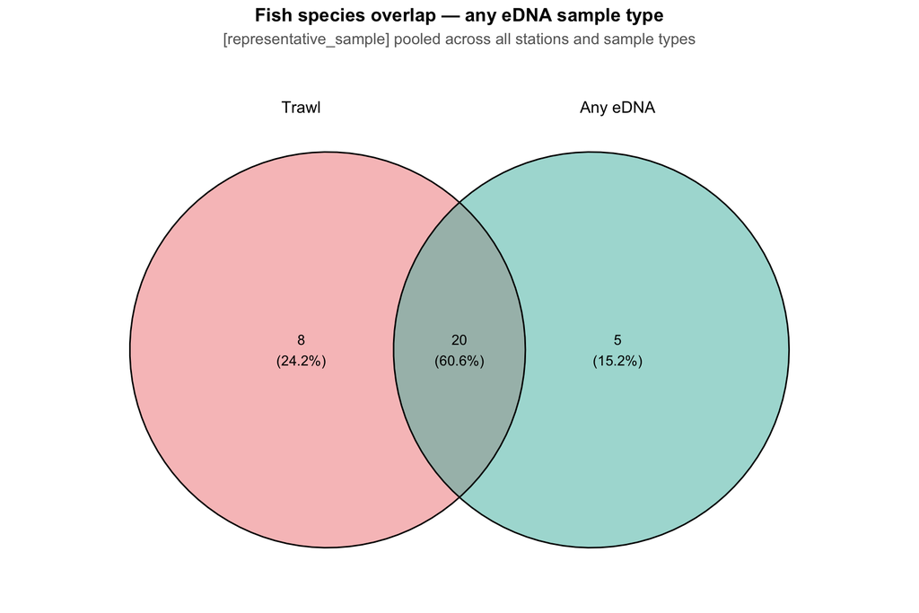

### Overall Spearman ρ [ representative_sample ]

Spearman ρ [representative_sample] (pooled = mean)

| Sample Type | Trawl metric | N obs. | ρ | p-value | Sig. |
| --- | --- | --- | --- | --- | --- |
| Bottom_metaprobe | Biomass | 85 | 0.508 | 7.00e-07 | *** |
|  | Count | 85 | 0.599 | 0.00e+00 | *** |
| Pooled (mean) | Biomass | 136 | 0.566 | 0.00e+00 | *** |
|  | Count | 136 | 0.631 | 0.00e+00 | *** |
| Slush | Biomass | 19 | 0.828 | 1.18e-05 | *** |
|  | Count | 19 | 0.864 | 1.90e-06 | *** |
| Top_metaprobe | Biomass | 59 | 0.509 | 3.77e-05 | *** |
|  | Count | 59 | 0.614 | 2.00e-07 | *** |

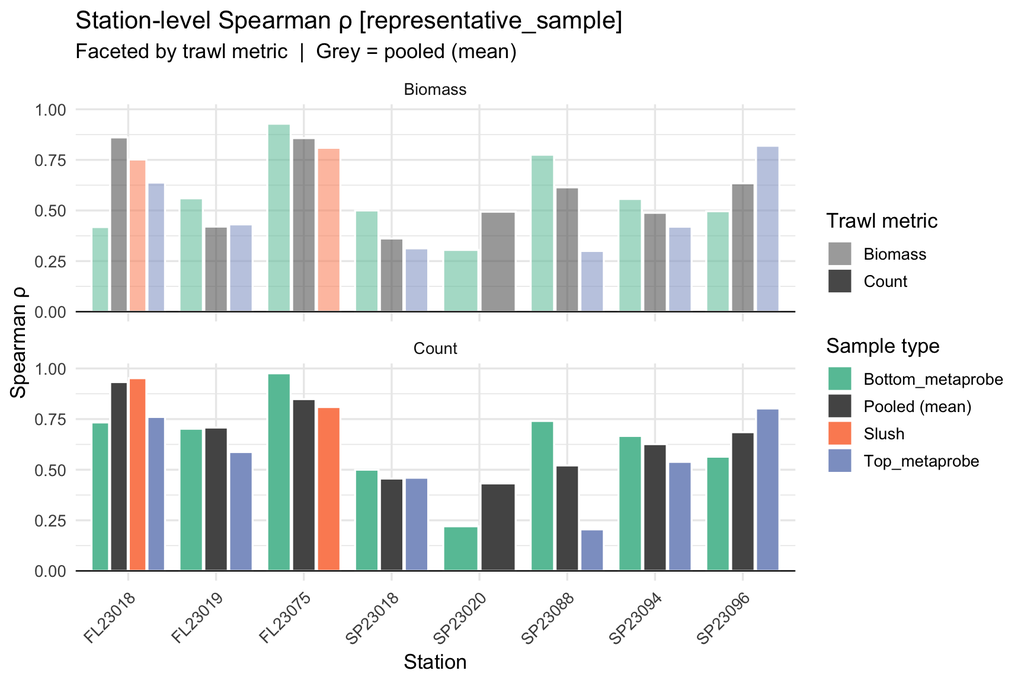

### Relative Abundance Barplots [ representative_sample ]

Trawl species for barplot: Alosa spp., Amblyraja radiata, Atractosteus spatula, Clupea harengus, Cyclopterus lumpus, Dipturus laevis, Enchelyopus cimbrius, Gadus morhua, Glyptocephalus cynoglossus, Hemitripterinae, Hippoglossina oblonga, Hippoglossoides platessoides, Hippoglossus hippoglossus, Leucoraja erinacea, Lophius americanus, Melanogrammus aeglefinus, Merluccius bilinearis, Myoxocephalus spp., Peprilus triacanthus, Pleuronectes ferruginea, Pollachius pollachius, Pseudopleuronectes americanus, Scophthalmus aquosus, Sebastes spp., Squalus acanthias, Urophycis chuss, Urophycis tenuis

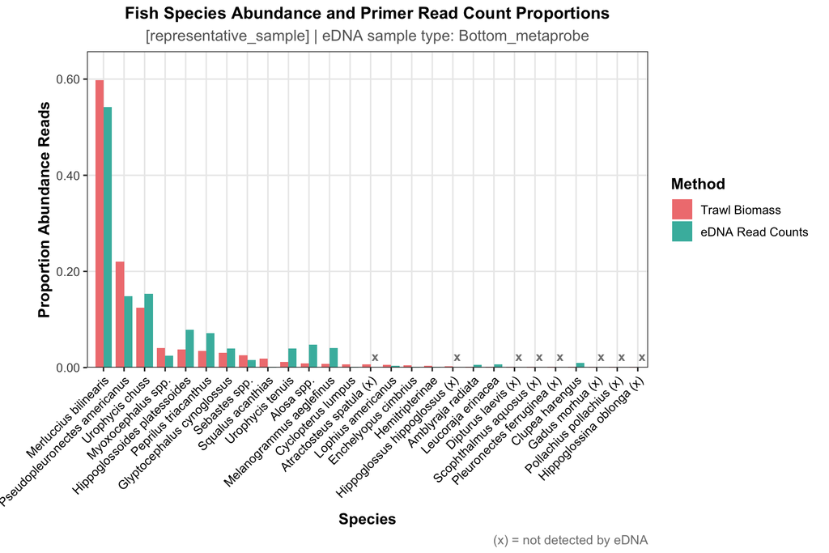

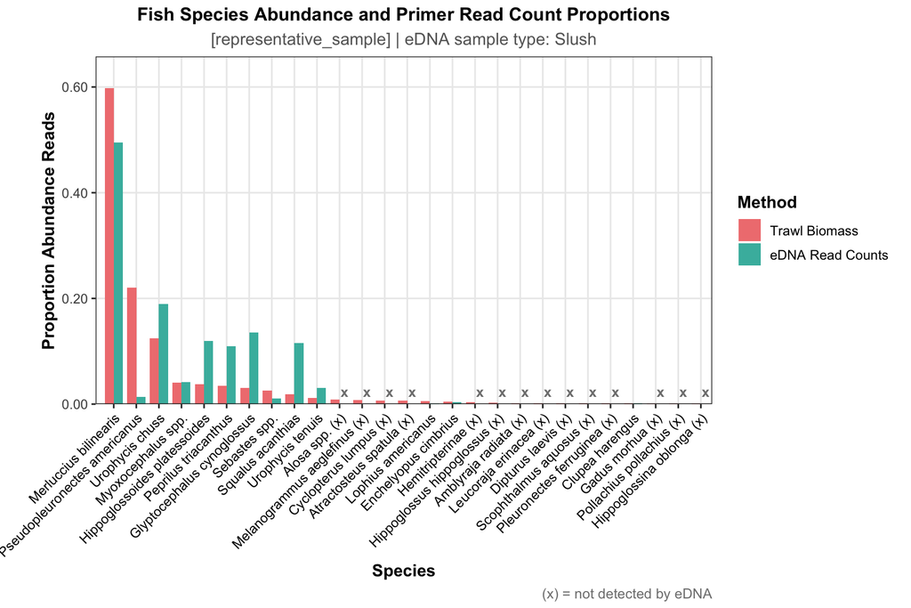

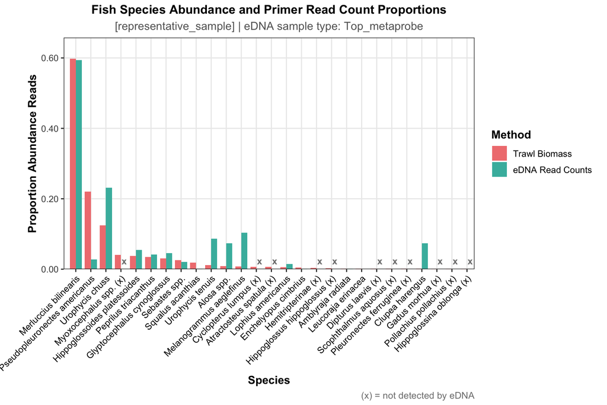

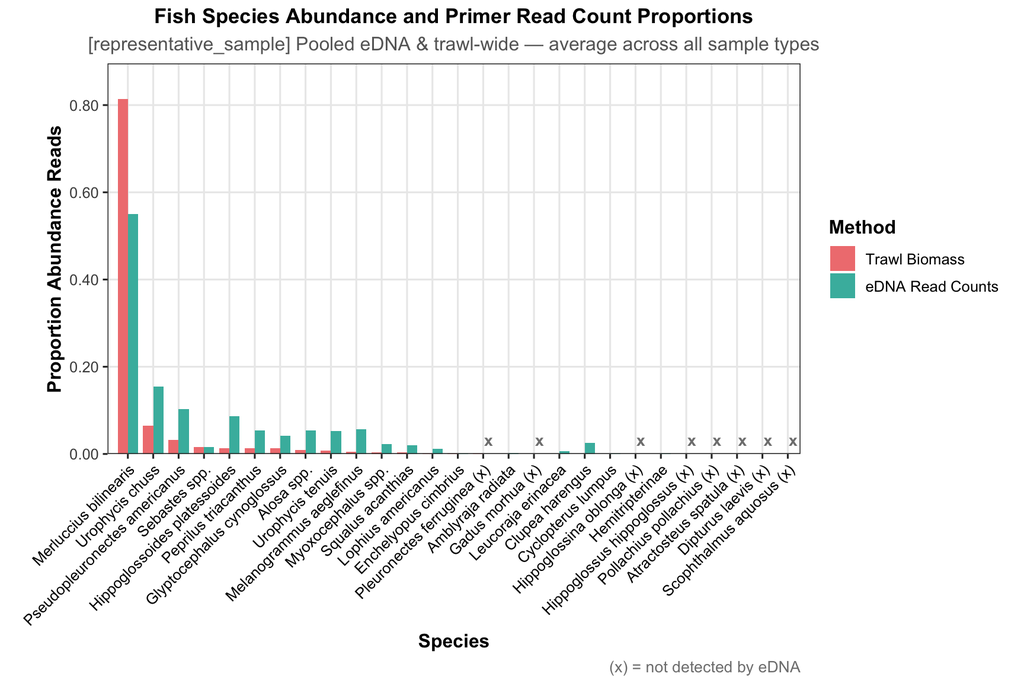

By-station export [ representative_sample ] — rows: 118 | stations: 9 | species: 27 Exported: relative_reads_fish_trawl_species_representative_sample_by_station.csv Exported: relative_reads_fish_trawl_species_representative_sample_trawl_wide.csv

By-station [representative_sample] — first 15 rows

| trawl_id | species | trawl_count | trawl_weight | trawl_count_rel | trawl_weight_rel | bottom_metaprobe_rel_reads | slush_rel_reads | top_metaprobe_rel_reads | best_rel_reads |
| --- | --- | --- | --- | --- | --- | --- | --- | --- | --- |
| FL23018 | Enchelyopus cimbrius | 6 | 0.310 | 0.00824 | 0.00148 | 0.00022 | 0.00356 | 0.00043 | 0.00140 |
| FL23018 | Glyptocephalus cynoglossus | 61 | 13.670 | 0.08379 | 0.06547 | 0.07685 | 0.13506 | 0.06041 | 0.09055 |
| FL23018 | Hippoglossoides platessoides | 58 | 28.540 | 0.07967 | 0.13668 | 0.02829 | 0.11957 | 0.11846 | 0.08855 |
| FL23018 | Lophius americanus | 4 | 6.200 | 0.00549 | 0.02969 | 0.00531 | 0.00021 | 0.01066 | 0.00538 |
| FL23018 | Merluccius bilinearis | 300 | 31.612 | 0.41209 | 0.15140 | 0.56616 | 0.20269 | 0.29451 | 0.35357 |
| FL23018 | Sebastes spp. | 13 | 1.570 | 0.01786 | 0.00752 | 0.00489 | 0.01072 | 0.03007 | 0.01519 |
| FL23018 | Squalus acanthias | 19 | 28.590 | 0.02610 | 0.13692 | 0.00004 | 0.11513 | 0.00021 | 0.03836 |
| FL23018 | Urophycis chuss | 250 | 44.910 | 0.34341 | 0.21508 | 0.31443 | 0.36709 | 0.45569 | 0.37812 |
| FL23018 | Urophycis tenuis | 17 | 53.400 | 0.02335 | 0.25574 | 0.00376 | 0.03967 | 0.02492 | 0.02273 |
| FL23019 | Amblyraja radiata | 2 | 8.380 | 0.00370 | 0.04135 | 0.00529 | 0.00000 | 0.00000 | 0.00266 |
| FL23019 | Dipturus laevis | 1 | 1.140 | 0.00185 | 0.00562 | 0.00000 | 0.00000 | 0.00000 | 0.00000 |
| FL23019 | Enchelyopus cimbrius | 5 | 0.250 | 0.00924 | 0.00123 | 0.00062 | 0.00000 | 0.00000 | 0.00031 |
| FL23019 | Glyptocephalus cynoglossus | 53 | 12.650 | 0.09797 | 0.06242 | 0.12557 | 0.00000 | 0.11077 | 0.05934 |
| FL23019 | Hippoglossoides platessoides | 77 | 35.060 | 0.14233 | 0.17299 | 0.11574 | 0.00000 | 0.03239 | 0.03719 |
| FL23019 | Lophius americanus | 8 | 3.680 | 0.01479 | 0.01816 | 0.00526 | 0.00000 | 0.00428 | 0.00240 |

Trawl-wide means [representative_sample]

| sample_type | species | n_trawl_stations | n_trawl_stations_nonzero | mean_trawl_count | sd_trawl_count | mean_trawl_weight | sd_trawl_weight | mean_trawl_count_rel | sd_trawl_count_rel | mean_trawl_weight_rel | sd_trawl_weight_rel | n_edna_stations | n_edna_stations_detected | mean_edna_rel_read_count | sd_edna_rel_read_count |
| --- | --- | --- | --- | --- | --- | --- | --- | --- | --- | --- | --- | --- | --- | --- | --- |
| Bottom_metaprobe | Merluccius bilinearis | 9 | 9 | 1397.11111 | 1606.30970 | 105.43311 | 123.34268 | 0.59802 | 0.31875 | 0.45945 | 0.35239 | 9 | 9 | 0.60329 | 0.22935 |
| Bottom_metaprobe | Urophycis chuss | 9 | 9 | 110.44444 | 76.60958 | 16.77244 | 15.82019 | 0.12472 | 0.12370 | 0.09414 | 0.06804 | 9 | 7 | 0.13482 | 0.12581 |
| Bottom_metaprobe | Pseudopleuronectes americanus | 9 | 5 | 54.22222 | 107.60202 | 6.61444 | 12.35143 | 0.12262 | 0.23648 | 0.15449 | 0.29437 | 9 | 4 | 0.08078 | 0.12702 |
| Bottom_metaprobe | Hippoglossoides platessoides | 9 | 7 | 23.44444 | 27.67721 | 10.04333 | 13.09961 | 0.02946 | 0.04931 | 0.05232 | 0.06464 | 9 | 4 | 0.04958 | 0.10181 |
| Bottom_metaprobe | Urophycis tenuis | 9 | 9 | 13.44444 | 9.65804 | 12.76867 | 21.91971 | 0.01185 | 0.00827 | 0.06475 | 0.10479 | 9 | 6 | 0.03140 | 0.05288 |
| Bottom_metaprobe | Melanogrammus aeglefinus | 9 | 4 | 8.44444 | 18.49399 | 5.12889 | 12.76709 | 0.00353 | 0.00645 | 0.02121 | 0.04527 | 9 | 5 | 0.03127 | 0.05791 |
| Bottom_metaprobe | Glyptocephalus cynoglossus | 9 | 7 | 21.55556 | 25.05050 | 3.88667 | 5.52952 | 0.02422 | 0.03831 | 0.01893 | 0.02642 | 9 | 6 | 0.02793 | 0.04382 |
| Bottom_metaprobe | Alosa spp. | 18 | 16 | 7.44444 | 12.71508 | 0.66244 | 1.43045 | 0.00776 | 0.01312 | 0.00532 | 0.00995 | 9 | 5 | 0.02416 | 0.02922 |
| Bottom_metaprobe | Peprilus triacanthus | 9 | 3 | 22.55556 | 66.91807 | 1.51333 | 4.49134 | 0.01149 | 0.03195 | 0.00943 | 0.02633 | 9 | 2 | 0.01692 | 0.04340 |
| Bottom_metaprobe | Myoxocephalus spp. | 9 | 4 | 7.44444 | 11.35904 | 1.13000 | 1.74770 | 0.01787 | 0.03768 | 0.02712 | 0.05204 | 9 | 3 | 0.00847 | 0.01715 |
| Bottom_metaprobe | Sebastes spp. | 9 | 7 | 28.44444 | 53.01205 | 2.22778 | 3.30003 | 0.02020 | 0.02960 | 0.01435 | 0.02199 | 9 | 3 | 0.00530 | 0.00951 |
| Bottom_metaprobe | Clupea harengus | 9 | 1 | 0.33333 | 1.00000 | 0.02778 | 0.08333 | 0.00016 | 0.00048 | 0.00016 | 0.00049 | 9 | 3 | 0.00329 | 0.00863 |
| Bottom_metaprobe | Leucoraja erinacea | 9 | 1 | 0.44444 | 1.33333 | 0.33778 | 1.01333 | 0.00021 | 0.00064 | 0.00199 | 0.00597 | 9 | 3 | 0.00235 | 0.00694 |
| Bottom_metaprobe | Lophius americanus | 9 | 7 | 2.55556 | 2.55495 | 1.43044 | 2.13226 | 0.00436 | 0.00578 | 0.00925 | 0.01042 | 9 | 4 | 0.00170 | 0.00239 |
| Bottom_metaprobe | Amblyraja radiata | 9 | 2 | 0.44444 | 0.88192 | 1.83222 | 3.63633 | 0.00048 | 0.00122 | 0.00770 | 0.01565 | 9 | 1 | 0.00059 | 0.00176 |
| Bottom_metaprobe | Squalus acanthias | 9 | 4 | 5.22222 | 9.65373 | 8.19111 | 15.03464 | 0.00817 | 0.01664 | 0.04005 | 0.07351 | 9 | 2 | 0.00013 | 0.00039 |
| Bottom_metaprobe | Enchelyopus cimbrius | 9 | 5 | 2.22222 | 2.53859 | 0.11533 | 0.12917 | 0.00237 | 0.00370 | 0.00057 | 0.00064 | 9 | 3 | 0.00011 | 0.00021 |
| Bottom_metaprobe | Hemitripterinae | 9 | 2 | 0.22222 | 0.44096 | 0.02778 | 0.05954 | 0.00080 | 0.00222 | 0.00077 | 0.00197 | 9 | 1 | 0.00008 | 0.00024 |
| Bottom_metaprobe | Cyclopterus lumpus | 9 | 2 | 0.33333 | 0.70711 | 0.13444 | 0.27925 | 0.00151 | 0.00447 | 0.00648 | 0.01905 | 9 | 1 | 0.00007 | 0.00020 |
| Bottom_metaprobe | Atractosteus spatula | 9 | 1 | 0.11111 | 0.33333 | 0.00067 | 0.00200 | 0.00075 | 0.00224 | 0.00005 | 0.00015 | 9 | 0 | 0.00000 | 0.00000 |
| Bottom_metaprobe | Dipturus laevis | 9 | 1 | 0.11111 | 0.33333 | 0.12667 | 0.38000 | 0.00021 | 0.00062 | 0.00062 | 0.00187 | 9 | 0 | 0.00000 | 0.00000 |
| Bottom_metaprobe | Gadus morhua | 9 | 2 | 0.44444 | 0.88192 | 0.61778 | 1.80877 | 0.00026 | 0.00058 | 0.00219 | 0.00623 | 9 | 0 | 0.00000 | 0.00000 |
| Bottom_metaprobe | Hippoglossina oblonga | 9 | 3 | 0.33333 | 0.50000 | 0.01689 | 0.02867 | 0.00012 | 0.00019 | 0.00007 | 0.00014 | 9 | 0 | 0.00000 | 0.00000 |
| Bottom_metaprobe | Hippoglossus hippoglossus | 9 | 1 | 0.22222 | 0.66667 | 0.11778 | 0.35333 | 0.00035 | 0.00106 | 0.00220 | 0.00660 | 9 | 0 | 0.00000 | 0.00000 |
| Bottom_metaprobe | Pleuronectes ferruginea | 9 | 3 | 0.66667 | 1.11803 | 0.13111 | 0.22200 | 0.00049 | 0.00078 | 0.00071 | 0.00131 | 9 | 0 | 0.00000 | 0.00000 |
| Bottom_metaprobe | Pollachius pollachius | 9 | 2 | 0.22222 | 0.44096 | 0.05600 | 0.11113 | 0.00009 | 0.00019 | 0.00028 | 0.00059 | 9 | 0 | 0.00000 | 0.00000 |
| Bottom_metaprobe | Scophthalmus aquosus | 9 | 1 | 0.11111 | 0.33333 | 0.00333 | 0.01000 | 0.00018 | 0.00053 | 0.00006 | 0.00019 | 9 | 0 | 0.00000 | 0.00000 |
| Slush | Merluccius bilinearis | 9 | 9 | 1397.11111 | 1606.30970 | 105.43311 | 123.34268 | 0.59802 | 0.31875 | 0.45945 | 0.35239 | 9 | 2 | 0.11002 | 0.26275 |
| Slush | Urophycis chuss | 9 | 9 | 110.44444 | 76.60958 | 16.77244 | 15.82019 | 0.12472 | 0.12370 | 0.09414 | 0.06804 | 9 | 2 | 0.04208 | 0.12194 |
| Slush | Glyptocephalus cynoglossus | 9 | 7 | 21.55556 | 25.05050 | 3.88667 | 5.52952 | 0.02422 | 0.03831 | 0.01893 | 0.02642 | 9 | 1 | 0.01501 | 0.04502 |

[output cut: 51 more lines]

## Strategy: average

eDNA sample types: Bottom_metaprobe, Slush, Top_metaprobe eDNA stations: 9 Paired stations (trawl ∩ eDNA): 9 Species × station pairs detected by both methods: 127 Pooling strategy: mean Stations in pooled dataset: 9

### Species overlap per station

Species detected per station [average]

| Station | eDNA sample type | Trawl spp. | eDNA spp. | Shared spp. | % Shared |
| --- | --- | --- | --- | --- | --- |
| FL23018 | Bottom_metaprobe | 9 | 10 | 9 | 100% |
|  | Slush | 9 | 11 | 9 | 100% |
|  | Top_metaprobe | 9 | 13 | 9 | 100% |
| FL23019 | Bottom_metaprobe | 12 | 14 | 10 | 83.3% |
|  | Slush | 12 | 0 | 0 | — |
|  | Top_metaprobe | 12 | 11 | 8 | 66.7% |
| FL23020 | Bottom_metaprobe | 13 | — | — | — |
|  | Slush | 13 | — | — | — |
|  | Top_metaprobe | 13 | — | — | — |
| FL23075 | Bottom_metaprobe | 13 | 8 | 8 | 61.5% |
|  | Slush | 13 | 8 | 8 | 61.5% |
|  | Top_metaprobe | 13 | 0 | 0 | — |
| SP23018 | Bottom_metaprobe | 15 | 3 | 2 | 13.3% |
|  | Slush | 15 | 0 | 0 | — |
|  | Top_metaprobe | 15 | 10 | 9 | 60% |
| SP23019 | Bottom_metaprobe | 14 | 1 | 1 | 7.1% |
|  | Slush | 14 | 0 | 0 | — |
|  | Top_metaprobe | 14 | 1 | 1 | 7.1% |
| SP23020 | Bottom_metaprobe | 16 | 9 | 6 | 37.5% |
|  | Slush | 16 | 0 | 0 | — |
|  | Top_metaprobe | 16 | 1 | 1 | 6.2% |
| SP23088 | Bottom_metaprobe | 13 | 10 | 8 | 61.5% |
|  | Slush | 13 | 0 | 0 | — |
|  | Top_metaprobe | 13 | 5 | 4 | 30.8% |
| SP23094 | Bottom_metaprobe | 14 | 16 | 11 | 78.6% |
|  | Slush | 14 | 0 | 0 | — |
|  | Top_metaprobe | 14 | 12 | 10 | 71.4% |
| SP23096 | Bottom_metaprobe | 12 | 14 | 10 | 83.3% |
|  | Slush | 12 | 0 | 0 | — |
|  | Top_metaprobe | 12 | 6 | 3 | 25% |

### Species overlap Venn diagram [ average ]

Pooled across all stations and all eDNA sample types. A species is counted as eDNA-detected if present in ≥1 sample at ≥1 station.

Trawl only (8):Atractosteus spatula, Dipturus laevis, Gadus morhua, Hippoglossina oblonga, Hippoglossus hippoglossus, Pleuronectes ferruginea, Pollachius pollachius, Scophthalmus aquosus eDNA only (5):Brevoortia tyrannus, Cyprinus carpio, Homo sapiens, Melanostigma atlanticum, Scomber scombrus Both (20):Alosa spp., Amblyraja radiata, Clupea harengus, Cryptacanthodes maculatus, Cyclopterus lumpus, Enchelyopus cimbrius, Glyptocephalus cynoglossus, Hemitripterinae, Hippoglossoides platessoides, Leucoraja erinacea, Lophius americanus, Melanogrammus aeglefinus, Merluccius bilinearis, Myoxocephalus spp., Peprilus triacanthus, Pseudopleuronectes americanus, Sebastes spp., Squalus acanthias, Urophycis chuss, Urophycis tenuis

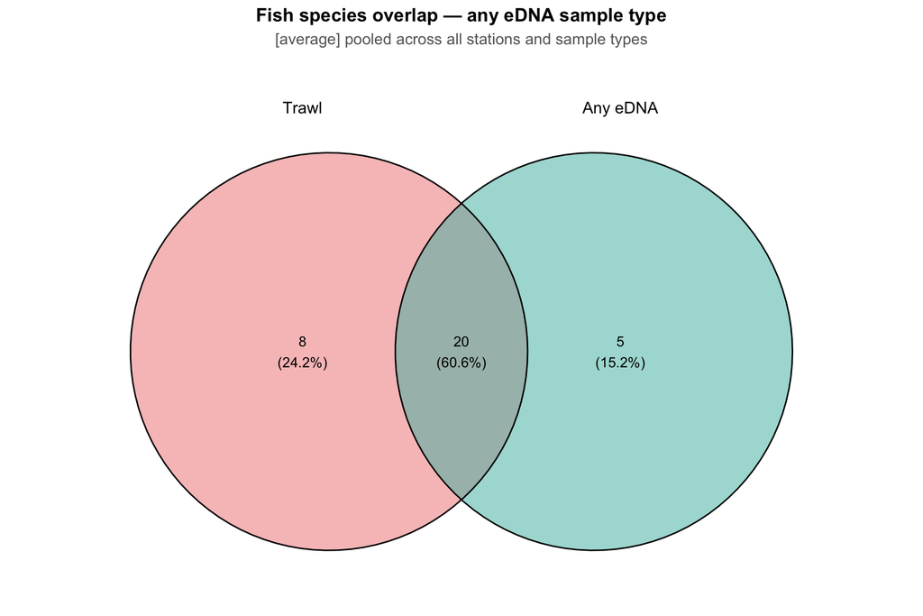

### Overall Spearman ρ [ average ]

Spearman ρ [average] (pooled = mean)

| Sample Type | Trawl metric | N obs. | ρ | p-value | Sig. |
| --- | --- | --- | --- | --- | --- |
| Bottom_metaprobe | Biomass | 85 | 0.508 | 7.00e-07 | *** |
|  | Count | 85 | 0.599 | 0.00e+00 | *** |
| Pooled (mean) | Biomass | 136 | 0.566 | 0.00e+00 | *** |
|  | Count | 136 | 0.631 | 0.00e+00 | *** |
| Slush | Biomass | 19 | 0.828 | 1.18e-05 | *** |
|  | Count | 19 | 0.864 | 1.90e-06 | *** |
| Top_metaprobe | Biomass | 59 | 0.509 | 3.77e-05 | *** |
|  | Count | 59 | 0.614 | 2.00e-07 | *** |

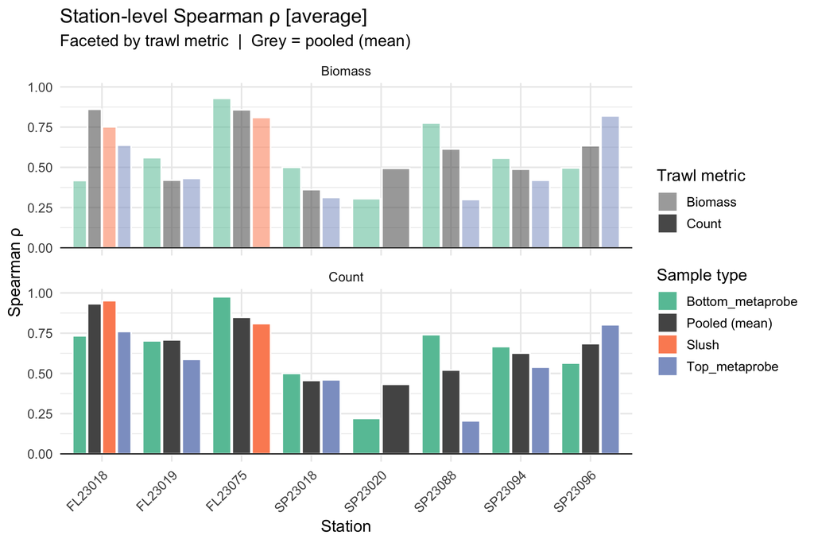

### Relative Abundance Barplots [ average ]

Trawl species for barplot: Alosa spp., Amblyraja radiata, Atractosteus spatula, Clupea harengus, Cyclopterus lumpus, Dipturus laevis, Enchelyopus cimbrius, Gadus morhua, Glyptocephalus cynoglossus, Hemitripterinae, Hippoglossina oblonga, Hippoglossoides platessoides, Hippoglossus hippoglossus, Leucoraja erinacea, Lophius americanus, Melanogrammus aeglefinus, Merluccius bilinearis, Myoxocephalus spp., Peprilus triacanthus, Pleuronectes ferruginea, Pollachius pollachius, Pseudopleuronectes americanus, Scophthalmus aquosus, Sebastes spp., Squalus acanthias, Urophycis chuss, Urophycis tenuis

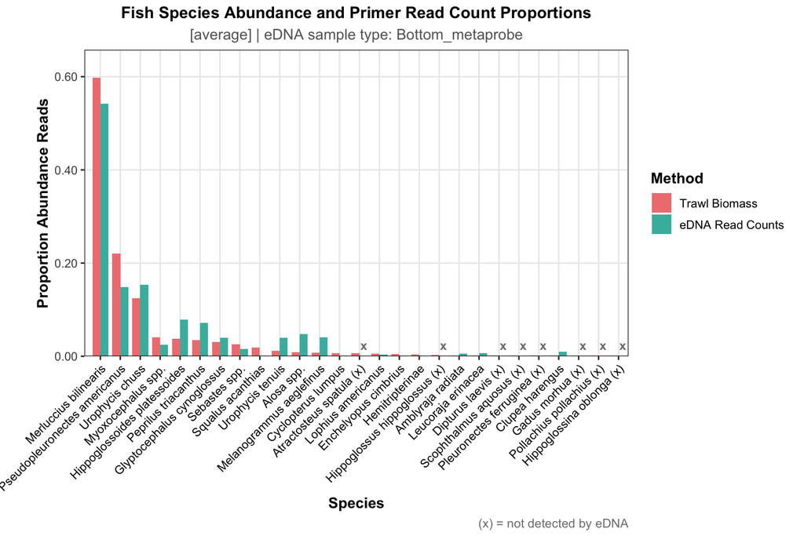

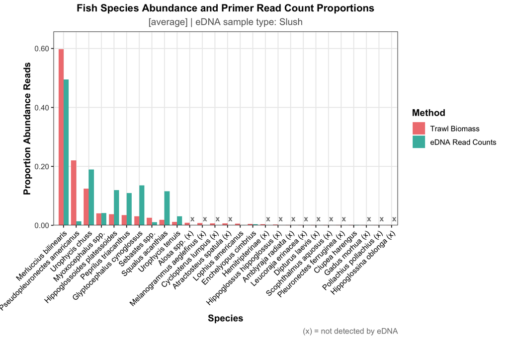

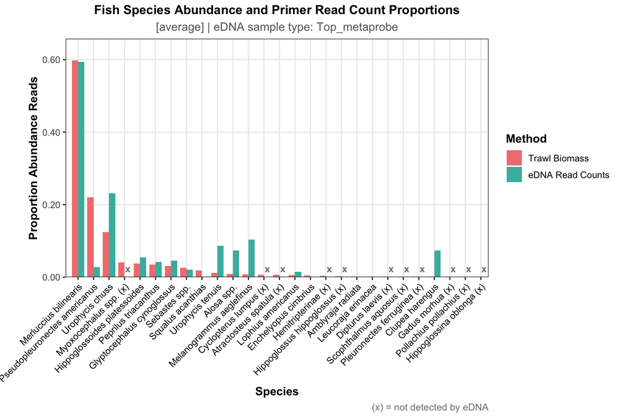

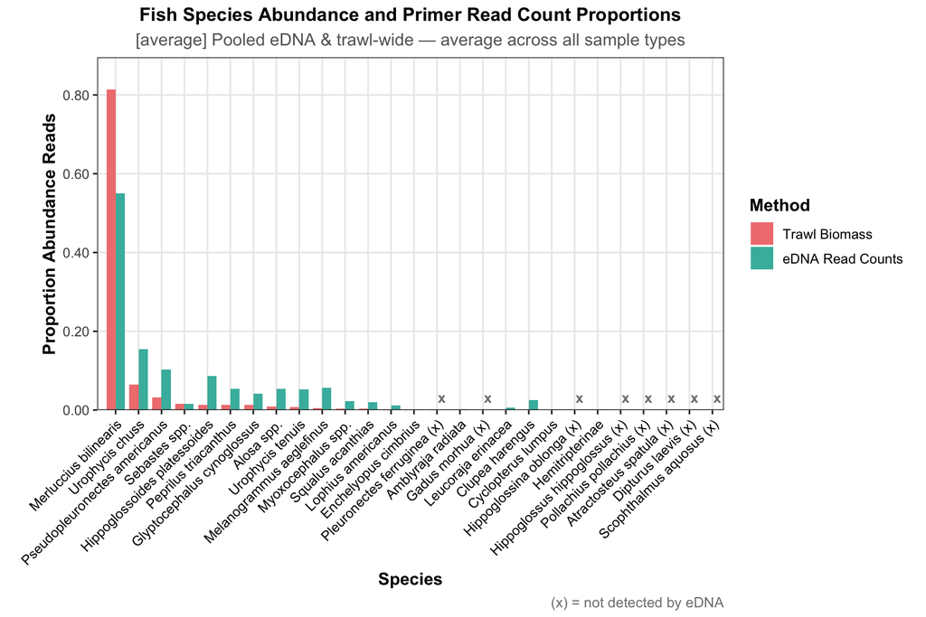

By-station export [ average ] — rows: 118 | stations: 9 | species: 27 Exported: relative_reads_fish_trawl_species_average_by_station.csv Exported: relative_reads_fish_trawl_species_average_trawl_wide.csv

By-station [average] — first 15 rows

| trawl_id | species | trawl_count | trawl_weight | trawl_count_rel | trawl_weight_rel | bottom_metaprobe_rel_reads | slush_rel_reads | top_metaprobe_rel_reads | best_rel_reads |
| --- | --- | --- | --- | --- | --- | --- | --- | --- | --- |
| FL23018 | Enchelyopus cimbrius | 6 | 0.310 | 0.00824 | 0.00148 | 0.00022 | 0.00356 | 0.00043 | 0.00140 |
| FL23018 | Glyptocephalus cynoglossus | 61 | 13.670 | 0.08379 | 0.06547 | 0.07685 | 0.13506 | 0.06041 | 0.09055 |
| FL23018 | Hippoglossoides platessoides | 58 | 28.540 | 0.07967 | 0.13668 | 0.02829 | 0.11957 | 0.11846 | 0.08855 |
| FL23018 | Lophius americanus | 4 | 6.200 | 0.00549 | 0.02969 | 0.00531 | 0.00021 | 0.01066 | 0.00538 |
| FL23018 | Merluccius bilinearis | 300 | 31.612 | 0.41209 | 0.15140 | 0.56616 | 0.20269 | 0.29451 | 0.35357 |
| FL23018 | Sebastes spp. | 13 | 1.570 | 0.01786 | 0.00752 | 0.00489 | 0.01072 | 0.03007 | 0.01519 |
| FL23018 | Squalus acanthias | 19 | 28.590 | 0.02610 | 0.13692 | 0.00004 | 0.11513 | 0.00021 | 0.03836 |
| FL23018 | Urophycis chuss | 250 | 44.910 | 0.34341 | 0.21508 | 0.31443 | 0.36709 | 0.45569 | 0.37812 |
| FL23018 | Urophycis tenuis | 17 | 53.400 | 0.02335 | 0.25574 | 0.00376 | 0.03967 | 0.02492 | 0.02273 |
| FL23019 | Amblyraja radiata | 2 | 8.380 | 0.00370 | 0.04135 | 0.00529 | 0.00000 | 0.00000 | 0.00266 |
| FL23019 | Dipturus laevis | 1 | 1.140 | 0.00185 | 0.00562 | 0.00000 | 0.00000 | 0.00000 | 0.00000 |
| FL23019 | Enchelyopus cimbrius | 5 | 0.250 | 0.00924 | 0.00123 | 0.00062 | 0.00000 | 0.00000 | 0.00031 |
| FL23019 | Glyptocephalus cynoglossus | 53 | 12.650 | 0.09797 | 0.06242 | 0.12557 | 0.00000 | 0.11077 | 0.05934 |
| FL23019 | Hippoglossoides platessoides | 77 | 35.060 | 0.14233 | 0.17299 | 0.11574 | 0.00000 | 0.03239 | 0.03719 |
| FL23019 | Lophius americanus | 8 | 3.680 | 0.01479 | 0.01816 | 0.00526 | 0.00000 | 0.00428 | 0.00240 |

Trawl-wide means [average]

| sample_type | species | n_trawl_stations | n_trawl_stations_nonzero | mean_trawl_count | sd_trawl_count | mean_trawl_weight | sd_trawl_weight | mean_trawl_count_rel | sd_trawl_count_rel | mean_trawl_weight_rel | sd_trawl_weight_rel | n_edna_stations | n_edna_stations_detected | mean_edna_rel_read_count | sd_edna_rel_read_count |
| --- | --- | --- | --- | --- | --- | --- | --- | --- | --- | --- | --- | --- | --- | --- | --- |
| Bottom_metaprobe | Merluccius bilinearis | 9 | 9 | 1397.11111 | 1606.30970 | 105.43311 | 123.34268 | 0.59802 | 0.31875 | 0.45945 | 0.35239 | 9 | 9 | 0.60329 | 0.22935 |
| Bottom_metaprobe | Urophycis chuss | 9 | 9 | 110.44444 | 76.60958 | 16.77244 | 15.82019 | 0.12472 | 0.12370 | 0.09414 | 0.06804 | 9 | 7 | 0.13482 | 0.12581 |
| Bottom_metaprobe | Pseudopleuronectes americanus | 9 | 5 | 54.22222 | 107.60202 | 6.61444 | 12.35143 | 0.12262 | 0.23648 | 0.15449 | 0.29437 | 9 | 4 | 0.08078 | 0.12702 |
| Bottom_metaprobe | Hippoglossoides platessoides | 9 | 7 | 23.44444 | 27.67721 | 10.04333 | 13.09961 | 0.02946 | 0.04931 | 0.05232 | 0.06464 | 9 | 4 | 0.04958 | 0.10181 |
| Bottom_metaprobe | Urophycis tenuis | 9 | 9 | 13.44444 | 9.65804 | 12.76867 | 21.91971 | 0.01185 | 0.00827 | 0.06475 | 0.10479 | 9 | 6 | 0.03140 | 0.05288 |
| Bottom_metaprobe | Melanogrammus aeglefinus | 9 | 4 | 8.44444 | 18.49399 | 5.12889 | 12.76709 | 0.00353 | 0.00645 | 0.02121 | 0.04527 | 9 | 5 | 0.03127 | 0.05791 |
| Bottom_metaprobe | Glyptocephalus cynoglossus | 9 | 7 | 21.55556 | 25.05050 | 3.88667 | 5.52952 | 0.02422 | 0.03831 | 0.01893 | 0.02642 | 9 | 6 | 0.02793 | 0.04382 |
| Bottom_metaprobe | Alosa spp. | 18 | 16 | 7.44444 | 12.71508 | 0.66244 | 1.43045 | 0.00776 | 0.01312 | 0.00532 | 0.00995 | 9 | 5 | 0.02416 | 0.02922 |
| Bottom_metaprobe | Peprilus triacanthus | 9 | 3 | 22.55556 | 66.91807 | 1.51333 | 4.49134 | 0.01149 | 0.03195 | 0.00943 | 0.02633 | 9 | 2 | 0.01692 | 0.04340 |
| Bottom_metaprobe | Myoxocephalus spp. | 9 | 4 | 7.44444 | 11.35904 | 1.13000 | 1.74770 | 0.01787 | 0.03768 | 0.02712 | 0.05204 | 9 | 3 | 0.00847 | 0.01715 |
| Bottom_metaprobe | Sebastes spp. | 9 | 7 | 28.44444 | 53.01205 | 2.22778 | 3.30003 | 0.02020 | 0.02960 | 0.01435 | 0.02199 | 9 | 3 | 0.00530 | 0.00951 |
| Bottom_metaprobe | Clupea harengus | 9 | 1 | 0.33333 | 1.00000 | 0.02778 | 0.08333 | 0.00016 | 0.00048 | 0.00016 | 0.00049 | 9 | 3 | 0.00329 | 0.00863 |
| Bottom_metaprobe | Leucoraja erinacea | 9 | 1 | 0.44444 | 1.33333 | 0.33778 | 1.01333 | 0.00021 | 0.00064 | 0.00199 | 0.00597 | 9 | 3 | 0.00235 | 0.00694 |
| Bottom_metaprobe | Lophius americanus | 9 | 7 | 2.55556 | 2.55495 | 1.43044 | 2.13226 | 0.00436 | 0.00578 | 0.00925 | 0.01042 | 9 | 4 | 0.00170 | 0.00239 |
| Bottom_metaprobe | Amblyraja radiata | 9 | 2 | 0.44444 | 0.88192 | 1.83222 | 3.63633 | 0.00048 | 0.00122 | 0.00770 | 0.01565 | 9 | 1 | 0.00059 | 0.00176 |
| Bottom_metaprobe | Squalus acanthias | 9 | 4 | 5.22222 | 9.65373 | 8.19111 | 15.03464 | 0.00817 | 0.01664 | 0.04005 | 0.07351 | 9 | 2 | 0.00013 | 0.00039 |
| Bottom_metaprobe | Enchelyopus cimbrius | 9 | 5 | 2.22222 | 2.53859 | 0.11533 | 0.12917 | 0.00237 | 0.00370 | 0.00057 | 0.00064 | 9 | 3 | 0.00011 | 0.00021 |
| Bottom_metaprobe | Hemitripterinae | 9 | 2 | 0.22222 | 0.44096 | 0.02778 | 0.05954 | 0.00080 | 0.00222 | 0.00077 | 0.00197 | 9 | 1 | 0.00008 | 0.00024 |
| Bottom_metaprobe | Cyclopterus lumpus | 9 | 2 | 0.33333 | 0.70711 | 0.13444 | 0.27925 | 0.00151 | 0.00447 | 0.00648 | 0.01905 | 9 | 1 | 0.00007 | 0.00020 |
| Bottom_metaprobe | Atractosteus spatula | 9 | 1 | 0.11111 | 0.33333 | 0.00067 | 0.00200 | 0.00075 | 0.00224 | 0.00005 | 0.00015 | 9 | 0 | 0.00000 | 0.00000 |
| Bottom_metaprobe | Dipturus laevis | 9 | 1 | 0.11111 | 0.33333 | 0.12667 | 0.38000 | 0.00021 | 0.00062 | 0.00062 | 0.00187 | 9 | 0 | 0.00000 | 0.00000 |
| Bottom_metaprobe | Gadus morhua | 9 | 2 | 0.44444 | 0.88192 | 0.61778 | 1.80877 | 0.00026 | 0.00058 | 0.00219 | 0.00623 | 9 | 0 | 0.00000 | 0.00000 |
| Bottom_metaprobe | Hippoglossina oblonga | 9 | 3 | 0.33333 | 0.50000 | 0.01689 | 0.02867 | 0.00012 | 0.00019 | 0.00007 | 0.00014 | 9 | 0 | 0.00000 | 0.00000 |
| Bottom_metaprobe | Hippoglossus hippoglossus | 9 | 1 | 0.22222 | 0.66667 | 0.11778 | 0.35333 | 0.00035 | 0.00106 | 0.00220 | 0.00660 | 9 | 0 | 0.00000 | 0.00000 |
| Bottom_metaprobe | Pleuronectes ferruginea | 9 | 3 | 0.66667 | 1.11803 | 0.13111 | 0.22200 | 0.00049 | 0.00078 | 0.00071 | 0.00131 | 9 | 0 | 0.00000 | 0.00000 |
| Bottom_metaprobe | Pollachius pollachius | 9 | 2 | 0.22222 | 0.44096 | 0.05600 | 0.11113 | 0.00009 | 0.00019 | 0.00028 | 0.00059 | 9 | 0 | 0.00000 | 0.00000 |
| Bottom_metaprobe | Scophthalmus aquosus | 9 | 1 | 0.11111 | 0.33333 | 0.00333 | 0.01000 | 0.00018 | 0.00053 | 0.00006 | 0.00019 | 9 | 0 | 0.00000 | 0.00000 |
| Slush | Merluccius bilinearis | 9 | 9 | 1397.11111 | 1606.30970 | 105.43311 | 123.34268 | 0.59802 | 0.31875 | 0.45945 | 0.35239 | 9 | 2 | 0.11002 | 0.26275 |
| Slush | Urophycis chuss | 9 | 9 | 110.44444 | 76.60958 | 16.77244 | 15.82019 | 0.12472 | 0.12370 | 0.09414 | 0.06804 | 9 | 2 | 0.04208 | 0.12194 |
| Slush | Glyptocephalus cynoglossus | 9 | 7 | 21.55556 | 25.05050 | 3.88667 | 5.52952 | 0.02422 | 0.03831 | 0.01893 | 0.02642 | 9 | 1 | 0.01501 | 0.04502 |

[output cut: 51 more lines]